# Canadian Used Vehicles Price Prediction

September 12th, 2022.

# 1 Introduction

The outbreak of the COVID-19 pandemic crisis has brought significant socioeconomic effects on our society. Social distancing, self-isolation, and travel restrictions reduced the workforce across all economic sectors. The automobile industry is no exemption, a deviation in price movements for new and used cars was observed in several countries. Supply chain disruptions, notably for the semiconductor chips used in various components of newly manufactured vehicles, and pandemic-related plant closures continue to impact the manufacture of new vehicles, leading to reduced inventories. With fewer new cars and trucks available for purchase and lengthy delays for delivery of new vehicles purchased, consumers have sought used vehicles, driving up demand.

Our research topic for this project is Canadian Used Vehicles Price Analysis and Prediction. The goal of this project is to build a Canadian used vehicles prediction model. We will try to build different types of models and compare the results. We will also try to optimize the model by applying the techniques we learned in classes. We hope to provide used vehicle sellers or buyers with a reliable tool for decision-making and promoting fair trade.

## 1.1 Dataset

The data set is open source from Kaggle, originally collected by “Market Check”, an online data aggregator. MarketCheck’s automotive data covers 8 years of inventory across the US and Canada(We chose to only investigate the Canadian data in our project). Each day their systems crawl and aggregate inventory from over 65k dealer websites to deliver the most comprehensive and up-to-date depictions of market activity available anywhere. Our data set contains close to 400,000 sampling data points of the used cars in Canada collected by crawling from Canadian car dealers’ websites. Here is the URL to the $Kaggle dataset^{[3]}$.

License concerns for the Used vehicle dataset: Open data set from $Kaggle^{[3]}$ collected initially by “Market Check.”

The original data set contains 21 columns in the CSV format. However, some columns are irrelevant to our subject, so we decided to exclude those columns from the data set in the early stage of the project, for example: id, stock_no, engine_block, seller_name, street, city, state, etc. Below is some basic explanations of the variables that will be contained in the data set:

The response variable (Dependent): Price. The car price is listed on the website (quantitative variable). The data range of the price is from 0 to 1.29 M.

Explanatory variables (Independent):

1. Miles: The car miles/odometer is listed on the website (quantitative variable). The data range is from 0 to 2.3 M.
2. Year: Model Year of the car (quantitative variable, will transform it to the age of the vehicle). E.g., 2017, 2018.
3. Make: The brand of the car (qualitative variable). E.g., Nissan.
4. Model: The specific model of the car (qualitative variable). E.g., Altima.
5. Body type: Detailed type of car (qualitative variable). E.g., SUV, Pickup.
6. Vehicle type: Type of car (qualitative variable). E.g., Truck, Car.
7. Drive train: The car’s drivetrain (qualitative variable). E.g., 4WD.
8. Transmission: Qualitative variable. E.g., Automatic.
9. Engine size: Quantitative variable. The data range of engine size is from 0.6 to 8.4

Let us take a look at the data set by read in the csv file:

```r
original_df = read.csv("ca-dealers-used.csv")
# Drop the unnecessary columns
original_df = subset(original_df, select = -c(id,stock_no,trim,engine_block,fuel_type,seller_name,street,city,state,zip) )
head(original_df)
```

|  | vin | price | miles | year | make | model | body_type | vehicle_type | drivetrain | transmission | engine_size |
| --- | --- | --- | --- | --- | --- | --- | --- | --- | --- | --- | --- |
| 1 | 19UNC1B01HY800062 | 179999 | 9966 | 2017 | Acura | NSX | Coupe | Car | 4WD | Automatic | 3.5 |
| 2 | 19UNC1B02HY800023 | 179995 | 5988 | 2017 | Acura | NSX | Coupe | Car | 4WD | Automatic | 3.5 |
| 3 | 19UNC1B02HY800071 | 168528 | 24242 | 2017 | Acura | NSX | Coupe | Car | 4WD | Automatic | 3.5 |
| 4 | 19UNC1B02LY800001 | 220000 | 6637 | 2020 | Acura | NSX | Coupe | Car | 4WD | Automatic | 3.5 |
| 5 | 19UNC1B02LY800001 | 220000 | 6637 | 2020 | Acura | NSX | Coupe | Car | 4WD | Automatic | 3.5 |
| 6 | 19UNC1B03HY800063 | 155771 | 18281 | 2017 | Acura | NSX | Coupe | Car | 4WD | Automatic | 3.5 |

Since the data set was sampled over the last eight years, and there is a “Year” column representing the make year of the vehicle, we are concerned that the multi-linear regression model we are building might violate the “Independence Assumption.” However, the data set does NOT have any information about the collection date of each sample point, so we cannot apply any yearly inflation/interest rate to adjust the “Price” of the vehicle. Therefore, we decided to move on to build the model first and check the “Independence Assumption” with residuals vs. “Year” afterward. If we find the violation of the assumption, the plan is to apply the proper transformation on the “Price” variable.

## 1.2 Data Wrangling

Load in all the packages we will need below:

```r
library("tidyr")
library("dplyr")
library("stringr")
library("tibble")
library("ggplot2")
library("GGally")
library("lmtest")
library("mctest")
library("MASS")
library("plyr")
```

Check the basic dimension of the dataframe:

```r
dim(original_df)
```

```
## [1] 393603     11
```

Some of the vehicles were sampled multiple times, so we decided to drop the duplicates by “Vin” number

```r
original_df = original_df[!duplicated(original_df$vin), ]
dim(original_df)
```

```
## [1] 226691     11
```

Check the NA values in the original data frame:

```r
# Trim the leading and tailing white space if the column is 'chr' data type
original_df = original_df %>% mutate(across(where(is.character), str_trim))
# Replace all the empty string with 'NA'
original_df <- replace(original_df, original_df == '', NA)
# Check how many NA values in each column
na_count <-sapply(original_df, function(x) sum((is.na(x))))
na_count <- data.frame(na_count)
# Show the NA values summary
na_count
```

|  | na_count |
| --- | --- |
| vin | 0 |
| price | 22859 |
| miles | 12688 |
| year | 13 |
| make | 0 |
| model | 2867 |
| body_type | 20664 |
| vehicle_type | 22916 |
| drivetrain | 25989 |
| transmission | 24712 |

[output cut: 1 more lines]

Drop all the rows with NA values, check the NA values counts again:

```r
original_df = original_df %>% drop_na()
after_clean_na_count <-sapply(original_df, function(x) sum((is.na(x))))
after_clean_na_count <- data.frame(after_clean_na_count)
after_clean_na_count
```

|  | after_clean_na_count |
| --- | --- |
| vin | 0 |
| price | 0 |
| miles | 0 |
| year | 0 |
| make | 0 |
| model | 0 |
| body_type | 0 |
| vehicle_type | 0 |
| drivetrain | 0 |
| transmission | 0 |

[output cut: 1 more lines]

```r
original_df = subset(original_df, price <= 100000 & price >= 1000)
# Transform the 'Year' column to the 'age of the car'--'age' column:
original_df$age = 2022- original_df$year
original_df = subset(original_df, age <= 20)
original_df = subset(original_df, miles <= 300000)
```

Clean up some of the columns with ‘string’ type:

```r
# Apply 'toupper' function to all columns with 'string' type
chr_columns = c("make", "model", "body_type", "drivetrain", "transmission")
original_df[chr_columns] = lapply(original_df[chr_columns], toupper)

# Fix some of the bad character in the string for 'model', 'make', and 'body_type' columns
original_df$model = chartr("?", " ", original_df$model)
original_df$model = chartr(" ", "-", original_df$model)
original_df$make = chartr(" ", "_", original_df$make)
original_df$body_type = chartr(" ", "_", original_df$body_type)

# Fix the Van body type names
body_type_van_name_fix<- function(column) {
  dplyr::case_when(grepl("VAN", column) ~ 'VAN',
                   TRUE ~ column)
}
original_df$body_type = body_type_van_name_fix(original_df$body_type)

# Get the body_type that has at least 100 listings in our data set
body_type_df = data.frame(table(original_df$body_type))
cleaned_body_type_names = subset(body_type_df, Freq >= 100)$Var1
# Filter the data frame by body_type that has at least 100 listings
original_df = subset(original_df, body_type %in% cleaned_body_type_names)

# Clean up the model names in the 'model' column
model_name_fix<- function(column) {
  dplyr::case_when(grepl("350Z", column) ~ '350Z',
                   grepl("370Z", column) ~ '370Z',
                   "300M" == column ~ '300',
                   grepl("488", column) ~ '488',
                   (("500C" == column) | ("500X" == column) | ("500L" == column)) ~ '500',
                   grepl("6-SERIE", column) ~ '6-SERIES',
                   grepl("A3-", column) ~ 'A3',
                   grepl("A5-", column) ~ 'A5',
                   grepl("A6-", column) ~ 'A6',
                   grepl("ACCORD-", column) ~ 'ACCORD',
                   grepl("COMPASS", column) ~ 'COMPASS',
                   grepl("WRANGLER", column) ~ 'WRANGLER',
                   grepl("ALTIMA", column) ~ 'ALTIMA',
                   (grepl("AMG-GT", column) | grepl("AMG--GT", column)) ~ 'AMG-GT',
                   grepl("ATS-", column) ~ 'ATS',
                   grepl("C-CLASS-", column) ~ 'C-CLASS',
                   grepl("CAMRY-", column) ~ 'CAMRY',
                   grepl("CAYENNE-", column) ~ 'CAYENNE',
                   grepl("CIVIC-", column) ~ 'CIVIC',
                   "CL" == column ~ 'CL-CLASS',
                   "CLA" == column ~ 'CLA-CLASS',
                   "CLK" == column ~ 'CLK-CLASS',
                   grepl("CONTINENTAL-", column) ~ 'CONTINENTAL',
                   grepl("COROLLA-", column) ~ 'COROLLA',
                   (grepl("CTS", column)|grepl("CT4", column)|grepl("CT5", column)|grepl("CT6", column)) ~ 'CT',
                   grepl("DISCOVERY-", column) ~ 'DISCOVERY',
                   grepl("E-SERIES-", column) ~ 'E-SERIES',
                   grepl("ECLIPSE-", column) ~ 'ECLIPSE',
                   grepl("ECONOLINE-", column) ~ 'ECONOLINE',
                   grepl("ELANTRA-", column) ~ 'ELANTRA',
                   grepl("F-250-", column) ~ 'F-250',
                   grepl("F-350-", column) ~ 'F-350',
                   grepl("F-450-", column) ~ 'F-450',
                   grepl("F-550-", column) ~ 'F-550',
                   grepl("FORTE", column) ~ 'FORTE',
                   grepl("FUSION-", column) ~ 'FUSION',
                   grepl("GENESIS-", column) ~ 'GENESIS',
                   grepl("GLB", column) ~ 'GLB-CLASS',
                   grepl("GLC", column) ~ 'GLC-CLASS',
                   grepl("GLE", column) ~ 'GLE-CLASS',
                   grepl("GLS", column) ~ 'GLS-CLASS',
                   grepl("GOLF-", column) ~ 'GOLF',
                   grepl("HARDTOP-", column) ~ 'HARDTOP',
                   grepl("JETTA", column) ~ 'JETTA',
                   grepl("MALIBU-", column) ~ 'MALIBU',
                   grepl("MIRAGE-", column) ~ 'MIRAGE',
                   grepl("MURANO-", column) ~ 'MURANO',
                   grepl("MX-5-MIATA-", column) ~ 'MX-5-MIATA',
                   grepl("M4-", column) ~ 'M4',
                   grepl("M5-", column) ~ 'M5',
                   grepl("OPTIMA", column) ~ 'OPTIMA',
                   grepl("NX-", column) ~ 'NX',
                   grepl("NV-", column) ~ 'NV',
                   grepl("BEETLE", column) ~ 'BEETLE',
                   grepl("PACIFICA-", column) ~ 'PACIFICA',
                   grepl("PATHFINDER-", column) ~ 'PATHFINDER',
                   grepl("PRIUS-", column) ~ 'PRIUS',
                   grepl("PROMASTER-", column) ~ 'PROMASTER',
                   grepl("RAM-1500-", column) ~ 'RAM-1500',
                   grepl("RAM-2500-", column) ~ 'RAM-2500',
                   grepl("RAM-3500-", column) ~ 'RAM-3500',
                   grepl("REGAL-", column) ~ 'REGAL',
                   grepl("S5-", column) ~ 'S5',
                   grepl("SANTA-", column) ~ 'SANTA',
                   grepl("SAVANA-", column) ~ 'SAVANA',
                   grepl("SIERRA-1500", column) ~ 'SIERRA-1500',
                   grepl("SIERRA-2500", column) ~ 'SIERRA-2500',
                   grepl("SIERRA-3500", column) ~ 'SIERRA-3500',
                   grepl("SILVERADO-1500", column) ~ 'SILVERADO-1500',
                   grepl("SILVERADO-2500", column) ~ 'SILVERADO-2500',
                   grepl("SILVERADO-3500", column) ~ 'SILVERADO-3500',
                   grepl("SONATA-", column) ~ 'SONATA',
                   grepl("SPRINTER-", column) ~ 'SPRINTER',
                   grepl("TOWN-", column) ~ 'TOWN',
                   grepl("TRANSIT-", column) ~ 'TRANSIT',
                   grepl("UX-", column) ~ 'UX',
                   grepl("VERSA-", column) ~ 'VERSA',
                   grepl("WRX-", column) ~ 'WRX',
                   grepl("YARIS-", column) ~ 'YARIS',
                   grepl("YUKON-", column) ~ 'YUKON',
                   TRUE ~ column)
}

original_df$model = model_name_fix(original_df$model)
```

Perform some transformation to merge some columns to create some new columns: ‘make_model’, ‘make_body_type’ and ‘make_model_body_type’. These are for later use in case there are any multicolinearity between variables.

```r
# Merge 'make' and 'model' columns to be one single column
original_df$make_model <- paste(original_df$make,"|", original_df$model)
# Merge 'make' and 'Body type' columns to be one single column
original_df$make_body_type <- paste(original_df$make,"|", original_df$body_type)
# Merge 'make' and 'Body type' columns to be one single column
original_df$make_model_body_type <- paste(original_df$make,"|",original_df$model,"|", original_df$body_type)
```

Take a look at the final cleaned up data frame:

```r
# Get the cleaned up make_model names (Only keep the make_model that has at least 100 listings in our data set)
make_model_df = data.frame(table(original_df$make_model))
cleaned_make_model_names = subset(make_model_df, Freq >=100)$Var1
# Drop the unnecessary columns to get the cleaned up data frame
clean_df = subset(original_df, select = -c(year,model) )
# Filter the data set by make_model that has at least 100 listings in our data set
clean_df = subset(clean_df, make_model %in% cleaned_make_model_names)
head(clean_df,5)
```

|  | vin | price | miles | make | body_type | vehicle_type | drivetrain | transmission | engine_size | age | make_model | make_body_type | make_model_body_type |
| --- | --- | --- | --- | --- | --- | --- | --- | --- | --- | --- | --- | --- | --- |
| 17 | 1C3BC8FG0BN584106 | 6991 | 105060 | CHRYSLER | SEDAN | Car | FWD | AUTOMATIC | 3.6 | 11 | CHRYSLER \| 200 | CHRYSLER \| SEDAN | CHRYSLER \| 200 \| SEDAN |
| 18 | 1C3BC8FG9BN603123 | 6705 | 164708 | CHRYSLER | SEDAN | Car | FWD | AUTOMATIC | 3.6 | 11 | CHRYSLER \| 200 | CHRYSLER \| SEDAN | CHRYSLER \| 200 \| SEDAN |
| 19 | 1C6RD7FT0CS321705 | 12995 | 179000 | RAM | PICKUP | Truck | 4WD | AUTOMATIC | 5.7 | 10 | RAM \| RAM-1500 | RAM \| PICKUP | RAM \| RAM-1500 \| PICKUP |
| 20 | 1C6RD7KT9CS338184 | 21499 | 126500 | RAM | PICKUP | Truck | 4WD | AUTOMATIC | 5.7 | 10 | RAM \| RAM-1500 | RAM \| PICKUP | RAM \| RAM-1500 \| PICKUP |
| 21 | 1D7RV1CT6BS523296 | 19888 | 188407 | RAM | PICKUP | Truck | 4WD | AUTOMATIC | 5.7 | 11 | RAM \| RAM-1500 | RAM \| PICKUP | RAM \| RAM-1500 \| PICKUP |

Due to the size of our data frame, if we build a model with all data in the data set, the run time for building the model will take extremely long hours to finish, this is even worse for interaction model. Therefore, we decided to move on to randomly sample 5000 data points to build our model:

```r
set.seed(5000)
size = nrow(clean_df)
samplecardata = clean_df[sample(1:size)[1:5000],]
```

Only keep the ‘make_body_type’ that has over 30 listings in the data set:

```r
dftest = data.frame(table(samplecardata$make_body_type))
cleaned_body_type_names = subset(dftest, Freq > 30)$Var1
samplecardata = subset(samplecardata, make_body_type %in% cleaned_body_type_names)
```

Summary of all the variables in the model.

```r
samplecardata %>% summarize_all(n_distinct)
```

| vin | price | miles | make | body_type | vehicle_type | drivetrain | transmission | engine_size | age | make_model | make_body_type | make_model_body_type |
| --- | --- | --- | --- | --- | --- | --- | --- | --- | --- | --- | --- | --- |
| 4244 | 2174 | 3909 | 22 | 5 | 2 | 3 | 2 | 41 | 20 | 141 | 43 | 150 |

# 2 Methodology

Through the project, we will perform the following steps:

- Initial data analysis, we will be investigating all vehicle features and attributes (independent variables) in the data set that affect the used car price (response variable). This task includes data wrangling, trend investigation, and plotting.
- We will build multiple sets of additive regression models based on the investigation. Investigate the relationship between the predictors and response.
- Based on the understanding of the investigation in item b), we will further estimate the weight of all possible interactive regression models.
- Based on the investigation, we will build polynomial regression models to see if we could have a more accurate model.
- We will optimize and compare the regression models and conclude a final predictive model.
- For the model selected above, we will run regression diagnostics and verify below multiple linear regression assumption.

  ```
  -- Independence Assumption - Review residual against year (time)

  -- Linearity Assumptyion - Review residual plot

  -- Normality Assumption - Using the Shapiro-Wilk normality test

  -- Equal Variance Assumption (heteroscedasticity) - Using Breusch-Pagan test

  -- Multicollinearity - Using variance inflation factors (VIF)

  -- Outliers - check Cook’s distance and leverage.
  ```

- If the model does not satisfy any of these assumptions, we will review our workflow. If required, apply Box-cox transformation to fix the Heteroscedasticity and Non-Normality.
- Evaluate overall accuracy and utility of the model.

## 2.1 Modelling

### 2.1.1 First Order Model

We first ran linear regression on First order model using all predictors (quantitative variable: miles,age,engine_size and qualitative variable: vehicle_type,drive train,transmission,body_type,make)result and verified if Multicollinearity exist between these independents variables.

```r
#Initial model with all predictor variables
Fullmodel = lm(price~miles+age+engine_size+factor(vehicle_type)+factor(drivetrain)+factor(transmission)+factor(body_type)+factor(make), data = samplecardata)
summary(Fullmodel)
```

```
##
## Call:
## lm(formula = price ~ miles + age + engine_size + factor(vehicle_type) +
##     factor(drivetrain) + factor(transmission) + factor(body_type) +
##     factor(make), data = samplecardata)
##
## Residuals:
##    Min     1Q Median     3Q    Max
## -27331  -3737   -773   2712  47044
##
## Coefficients: (1 not defined because of singularities)
##                              Estimate Std. Error t value Pr(>|t|)
## (Intercept)                 2.784e+04  1.176e+03  23.672  < 2e-16 ***
## miles                      -6.470e-02  3.048e-03 -21.227  < 2e-16 ***
## age                        -1.971e+03  5.661e+01 -34.821  < 2e-16 ***
## engine_size                 5.325e+03  1.438e+02  37.031  < 2e-16 ***
## factor(vehicle_type)Truck  -5.785e+02  1.074e+03  -0.539 0.590064
## factor(drivetrain)FWD      -3.232e+03  3.572e+02  -9.050  < 2e-16 ***
## factor(drivetrain)RWD      -6.484e+03  1.127e+03  -5.754 9.36e-09 ***
## factor(transmission)MANUAL  2.090e+03  4.554e+02   4.590 4.56e-06 ***
## factor(body_type)PICKUP     6.860e+03  1.138e+03   6.028 1.80e-09 ***
## factor(body_type)SEDAN     -1.235e+03  4.386e+02  -2.815 0.004902 **
## factor(body_type)SUV        1.840e+03  9.935e+02   1.853 0.064008 .
## factor(body_type)VAN               NA         NA      NA       NA
## factor(make)AUDI            4.937e+03  1.382e+03   3.571 0.000359 ***
## factor(make)BMW             9.508e+03  1.116e+03   8.519  < 2e-16 ***
## factor(make)BUICK          -1.581e+03  1.404e+03  -1.126 0.260060
## factor(make)CHEVROLET      -3.653e+03  1.064e+03  -3.432 0.000605 ***
## factor(make)CHRYSLER       -4.475e+03  1.539e+03  -2.908 0.003654 **
## factor(make)DODGE          -6.826e+03  1.266e+03  -5.391 7.39e-08 ***
## factor(make)FORD           -1.393e+03  1.051e+03  -1.326 0.184912
## factor(make)GMC            -3.536e+03  1.165e+03  -3.035 0.002421 **
## factor(make)HONDA          -3.187e+02  1.069e+03  -0.298 0.765678
## factor(make)HYUNDAI        -4.681e+03  1.061e+03  -4.411 1.06e-05 ***
## factor(make)JEEP            6.148e+00  1.088e+03   0.006 0.995490
## factor(make)KIA            -6.165e+03  1.084e+03  -5.687 1.38e-08 ***
## factor(make)LAND_ROVER      2.217e+04  1.417e+03  15.646  < 2e-16 ***
## factor(make)LEXUS           7.925e+03  1.400e+03   5.661 1.61e-08 ***
## factor(make)MAZDA          -5.138e+03  1.109e+03  -4.635 3.67e-06 ***
## factor(make)MERCEDES-BENZ   9.645e+03  1.137e+03   8.482  < 2e-16 ***
## factor(make)NISSAN         -5.495e+03  1.046e+03  -5.251 1.59e-07 ***
## factor(make)RAM            -6.792e+03  1.207e+03  -5.627 1.95e-08 ***
## factor(make)SUBARU         -2.619e+03  1.444e+03  -1.814 0.069804 .
## factor(make)TOYOTA         -1.081e+03  1.060e+03  -1.020 0.307841
## factor(make)VOLKSWAGEN     -7.708e+02  1.119e+03  -0.689 0.490976
## ---
## Signif. codes:  0 '***' 0.001 '**' 0.01 '*' 0.05 '.' 0.1 ' ' 1
##
## Residual standard error: 6404 on 4212 degrees of freedom
## Multiple R-squared:    0.8,  Adjusted R-squared:  0.7985
## F-statistic: 543.4 on 31 and 4212 DF,  p-value: < 2.2e-16
```

```r
imcdiag(Fullmodel,method="VIF")
```

```
##
## Call:
## imcdiag(mod = Fullmodel, method = "VIF")
##
##
##  VIF Multicollinearity Diagnostics
##
##                                VIF detection
## miles                       2.6790         0
## age                         2.7476         0
## engine_size                 2.9441         0
## factor(vehicle_type)Truck      Inf         1
## factor(drivetrain)FWD       3.1428         0
## factor(drivetrain)RWD       1.1052         0
## factor(transmission)MANUAL  1.1270         0
## factor(body_type)PICKUP        Inf         1
## factor(body_type)SEDAN      3.9238         0
## factor(body_type)SUV           Inf         1
## factor(body_type)VAN           Inf         1
## factor(make)AUDI            2.0744         0
## factor(make)BMW             5.1797         0
## factor(make)BUICK           1.9975         0
## factor(make)CHEVROLET       9.5590         0
## factor(make)CHRYSLER        1.8337         0
## factor(make)DODGE           6.9169         0
## factor(make)FORD           11.6050         1
## factor(make)GMC             4.1704         0
## factor(make)HONDA           8.2970         0
## factor(make)HYUNDAI         8.9549         0
## factor(make)JEEP            5.8089         0
## factor(make)KIA             7.0176         0
## factor(make)LAND_ROVER      1.9397         0
## factor(make)LEXUS           1.9876         0
## factor(make)MAZDA           5.1373         0
## factor(make)MERCEDES-BENZ   4.6204         0
## factor(make)NISSAN         10.1047         1
## factor(make)RAM             5.6008         0
## factor(make)SUBARU          1.9151         0
## factor(make)TOYOTA          8.8835         0
## factor(make)VOLKSWAGEN      5.3465         0
##
## Multicollinearity may be due to factor(vehicle_type)Truck factor(body_type)PICKUP factor(body_type)SUV factor(body_type)VAN factor(make)FORD factor(make)NISSAN regressors
##
## 1 --> COLLINEARITY is detected by the test
## 0 --> COLLINEARITY is not detected by the test
##
## ===================================
```

```r
#Reduced model with all predictor variables
reducedfomodel = lm(price~miles+age+engine_size+factor(drivetrain)+factor(transmission)+factor(make_body_type), data = samplecardata)
```

#### 2.1.1.1 Global F-Test

$$\begin{aligned}
H_0&:\beta_{Price}=\beta_{miles} = \beta_{age}
=\beta_{engine.size}=\beta_{drivetrain} =\beta_{transmission}=
\beta_{make.body.type} = 0 \\
H_a&:\mbox{at least one }\beta_i\mbox{ is not zero }
(i=miles,age,engine.size,drivetrain,transmission,make.body.type)
\end{aligned}$$

```r
#global F test
Nullfomodel = lm(price~1, data = samplecardata)
anova(Nullfomodel,reducedfomodel)
```

|  | Res.Df | RSS | Df | Sum of Sq | F | Pr(>F) |
| --- | --- | --- | --- | --- | --- | --- |
| 1 | 4243 | 863561254493 | NA | NA | NA | NA |
| 2 | 4195 | 167498176101 | 48 | 696063078393 | 363.1861 | 0 |

```r
#anovatable = as.data.frame(table1, row.names = make.unique(rownames(table1)))
```

[figure not shown]

Analysis of variance table 1 between Full model and Null Model

To begin the variable selection procedure, we conducted the global F-test comparing the selected model above with the null model. From the Anova table 1 above, P-value is less than the significant level (0.05). Thus, we have strong evidence to reject the null hypothesis and conclude that at least one of the predictor variables explains the Price of used vehicles. We ran the individual coefficient test on the selected model to find out which variables explain the price.

#### 2.1.1.2 Individual Coefficient Test

$$\begin{aligned}
H_0&:\beta_{i}=0\\
H_a&:\beta_{i} \ne 0
(i=miles,age,engine.size,drivetrain,transmission,make.body.type)
\end{aligned}$$

```r
#Partial T-test
summary(reducedfomodel)
```

```
##
## Call:
## lm(formula = price ~ miles + age + engine_size + factor(drivetrain) +
##     factor(transmission) + factor(make_body_type), data = samplecardata)
##
## Residuals:
##    Min     1Q Median     3Q    Max
## -27328  -3625   -616   2572  47701
##
## Coefficients:
##                                                Estimate Std. Error t value
## (Intercept)                                   2.897e+04  1.086e+03  26.678
## miles                                        -6.523e-02  3.015e-03 -21.637
## age                                          -1.979e+03  5.612e+01 -35.266
## engine_size                                   5.394e+03  1.444e+02  37.352
## factor(drivetrain)FWD                        -3.820e+03  3.852e+02  -9.915
## factor(drivetrain)RWD                        -5.916e+03  1.117e+03  -5.297
## factor(transmission)MANUAL                    2.275e+03  4.573e+02   4.976
## factor(make_body_type)AUDI | SUV              4.995e+03  1.364e+03   3.661
## factor(make_body_type)BMW | SEDAN             4.481e+03  1.244e+03   3.601
## factor(make_body_type)BMW | SUV               1.121e+04  1.159e+03   9.678
## factor(make_body_type)BUICK | SUV            -1.453e+03  1.385e+03  -1.049
## factor(make_body_type)CHEVROLET | HATCHBACK  -5.689e+03  1.391e+03  -4.089
## factor(make_body_type)CHEVROLET | PICKUP     -1.010e+03  1.242e+03  -0.813
## factor(make_body_type)CHEVROLET | SEDAN      -3.815e+03  1.206e+03  -3.163
## factor(make_body_type)CHEVROLET | SUV        -3.094e+03  1.130e+03  -2.738
## factor(make_body_type)CHRYSLER | SEDAN       -6.636e+03  1.521e+03  -4.362
## factor(make_body_type)DODGE | SUV            -6.532e+03  1.252e+03  -5.219
## factor(make_body_type)DODGE | VAN            -8.098e+03  1.204e+03  -6.726
## factor(make_body_type)FORD | PICKUP           5.526e+03  1.124e+03   4.916
## factor(make_body_type)FORD | SEDAN           -5.365e+03  1.293e+03  -4.149
## factor(make_body_type)FORD | SUV             -1.718e+03  1.056e+03  -1.627
## factor(make_body_type)GMC | PICKUP           -2.644e+02  1.277e+03  -0.207
## factor(make_body_type)GMC | SUV              -1.649e+03  1.265e+03  -1.304
## factor(make_body_type)HONDA | SEDAN          -2.691e+03  1.171e+03  -2.299
## factor(make_body_type)HONDA | SUV             2.869e+02  1.104e+03   0.260
## factor(make_body_type)HYUNDAI | HATCHBACK    -3.939e+03  1.541e+03  -2.555
## factor(make_body_type)HYUNDAI | SEDAN        -6.544e+03  1.181e+03  -5.542
## factor(make_body_type)HYUNDAI | SUV          -4.754e+03  1.090e+03  -4.360
## factor(make_body_type)JEEP | SUV             -3.284e+01  1.073e+03  -0.031
```

[output cut: 61 more lines]

```
## factor(make_body_type)NISSAN | SUV           2.73e-09 ***
## factor(make_body_type)RAM | PICKUP           0.083810 .
## factor(make_body_type)SUBARU | SUV           0.070921 .
## factor(make_body_type)TOYOTA | HATCHBACK     0.000733 ***
## factor(make_body_type)TOYOTA | SEDAN         0.008878 **
## factor(make_body_type)TOYOTA | SUV           0.970617
## factor(make_body_type)VOLKSWAGEN | HATCHBACK 0.987721
## factor(make_body_type)VOLKSWAGEN | SEDAN     0.007804 **
## factor(make_body_type)VOLKSWAGEN | SUV       0.671128
## ---
## Signif. codes:  0 '***' 0.001 '**' 0.01 '*' 0.05 '.' 0.1 ' ' 1
##
## Residual standard error: 6319 on 4195 degrees of freedom
## Multiple R-squared:  0.806,  Adjusted R-squared:  0.8038
## F-statistic: 363.2 on 48 and 4195 DF,  p-value: < 2.2e-16
```

The estimated model is
$$\begin {aligned}
\hat{Price}_{i}=\beta_{0}+\beta_{i}miles+\beta_{i}age+\beta_{i}engine.size+\\
\beta_{i1}drivetrain+\beta_{i2}transmission+\beta_{i3}make.body.type
\end {aligned}$$

### 2.1.2 Interaction Model

#### 2.1.2.1 Individual Coefficient Test

$$\begin{aligned}
H_0&:\beta_{i}=0\\
H_a&:\beta_{i} \ne 0
(i=miles,age,engine.size,drivetrain,transmission,make.body.type)
\end{aligned}$$

```r
#Partial T-test for interactions
intmodel = lm(price~(miles+age+engine_size+factor(drivetrain)+factor(transmission)+factor(make_body_type))^2, data = samplecardata)
summary(intmodel)
```

```
##
## Call:
## lm(formula = price ~ (miles + age + engine_size + factor(drivetrain) +
##     factor(transmission) + factor(make_body_type))^2, data = samplecardata)
##
## Residuals:
##    Min     1Q Median     3Q    Max
## -25479  -2296   -194   2000  40415
##
## Coefficients: (73 not defined because of singularities)
##                                                                           Estimate
## (Intercept)                                                              5.239e+04
## miles                                                                   -5.959e-02
## age                                                                     -2.456e+03
## engine_size                                                              1.993e+02
## factor(drivetrain)FWD                                                    5.129e+02
## factor(drivetrain)RWD                                                   -1.611e+04
## factor(transmission)MANUAL                                              -2.544e+01
## factor(make_body_type)AUDI | SUV                                        -2.878e+04
## factor(make_body_type)BMW | SEDAN                                       -2.143e+04
## factor(make_body_type)BMW | SUV                                         -2.472e+04
## factor(make_body_type)BUICK | SUV                                       -2.681e+04
## factor(make_body_type)CHEVROLET | HATCHBACK                             -4.521e+04
## factor(make_body_type)CHEVROLET | PICKUP                                -3.174e+04
## factor(make_body_type)CHEVROLET | SEDAN                                 -3.165e+04
## factor(make_body_type)CHEVROLET | SUV                                   -2.989e+04
## factor(make_body_type)CHRYSLER | SEDAN                                  -3.535e+04
## factor(make_body_type)DODGE | SUV                                       -3.062e+04
## factor(make_body_type)DODGE | VAN                                       -4.530e+04
## factor(make_body_type)FORD | PICKUP                                     -1.422e+04
## factor(make_body_type)FORD | SEDAN                                      -3.098e+04
## factor(make_body_type)FORD | SUV                                        -2.591e+04
## factor(make_body_type)GMC | PICKUP                                      -3.292e+04
## factor(make_body_type)GMC | SUV                                         -2.714e+04
## factor(make_body_type)HONDA | SEDAN                                     -2.349e+04
## factor(make_body_type)HONDA | SUV                                       -2.204e+04
## factor(make_body_type)HYUNDAI | HATCHBACK                               -3.928e+04
## factor(make_body_type)HYUNDAI | SEDAN                                   -4.456e+04
## factor(make_body_type)HYUNDAI | SUV                                     -2.796e+04
## factor(make_body_type)JEEP | SUV                                        -2.709e+04
```

[output cut: 1541 more lines]

```
## factor(transmission)MANUAL:factor(make_body_type)NISSAN | SUV
## factor(transmission)MANUAL:factor(make_body_type)RAM | PICKUP           ***
## factor(transmission)MANUAL:factor(make_body_type)SUBARU | SUV
## factor(transmission)MANUAL:factor(make_body_type)TOYOTA | HATCHBACK
## factor(transmission)MANUAL:factor(make_body_type)TOYOTA | SEDAN
## factor(transmission)MANUAL:factor(make_body_type)TOYOTA | SUV
## factor(transmission)MANUAL:factor(make_body_type)VOLKSWAGEN | HATCHBACK *
## factor(transmission)MANUAL:factor(make_body_type)VOLKSWAGEN | SEDAN
## factor(transmission)MANUAL:factor(make_body_type)VOLKSWAGEN | SUV
## ---
## Signif. codes:  0 '***' 0.001 '**' 0.01 '*' 0.05 '.' 0.1 ' ' 1
##
## Residual standard error: 4897 on 4002 degrees of freedom
## Multiple R-squared:  0.8889, Adjusted R-squared:  0.8822
## F-statistic: 132.8 on 241 and 4002 DF,  p-value: < 2.2e-16
```

```r
Fullintermodel = lm(price~miles+age+engine_size+factor(drivetrain)+factor(transmission)+factor(make_body_type)+miles:age+miles:engine_size+miles:factor(drivetrain)+miles:factor(transmission)+miles:factor(make_body_type)+age:engine_size+age:factor(drivetrain)+age:factor(transmission)+age:factor(make_body_type)+engine_size:factor(drivetrain)+engine_size:factor(transmission)+engine_size:factor(make_body_type)+factor(drivetrain):factor(transmission), data = samplecardata)
summary(Fullintermodel)
```

```
##
## Call:
## lm(formula = price ~ miles + age + engine_size + factor(drivetrain) +
##     factor(transmission) + factor(make_body_type) + miles:age +
##     miles:engine_size + miles:factor(drivetrain) + miles:factor(transmission) +
##     miles:factor(make_body_type) + age:engine_size + age:factor(drivetrain) +
##     age:factor(transmission) + age:factor(make_body_type) + engine_size:factor(drivetrain) +
##     engine_size:factor(transmission) + engine_size:factor(make_body_type) +
##     factor(drivetrain):factor(transmission), data = samplecardata)
##
## Residuals:
##    Min     1Q Median     3Q    Max
## -25774  -2334   -231   2054  40883
##
## Coefficients:
##                                                            Estimate Std. Error
## (Intercept)                                               5.244e+04  4.883e+03
## miles                                                    -6.310e-02  2.242e-02
## age                                                      -2.447e+03  4.675e+02
## engine_size                                               2.086e+02  1.646e+03
## factor(drivetrain)FWD                                    -1.982e+03  1.222e+03
## factor(drivetrain)RWD                                    -2.126e+03  6.719e+03
## factor(transmission)MANUAL                               -1.816e+03  1.686e+03
## factor(make_body_type)AUDI | SUV                         -2.869e+04  6.092e+03
## factor(make_body_type)BMW | SEDAN                        -2.038e+04  5.625e+03
## factor(make_body_type)BMW | SUV                          -2.441e+04  5.296e+03
## factor(make_body_type)BUICK | SUV                        -2.814e+04  5.649e+03
## factor(make_body_type)CHEVROLET | HATCHBACK              -4.297e+04  1.082e+04
## factor(make_body_type)CHEVROLET | PICKUP                 -3.364e+04  5.961e+03
## factor(make_body_type)CHEVROLET | SEDAN                  -2.938e+04  5.256e+03
## factor(make_body_type)CHEVROLET | SUV                    -2.986e+04  5.022e+03
## factor(make_body_type)CHRYSLER | SEDAN                   -3.363e+04  7.489e+03
## factor(make_body_type)DODGE | SUV                        -3.191e+04  5.773e+03
## factor(make_body_type)DODGE | VAN                        -4.283e+04  2.488e+04
## factor(make_body_type)FORD | PICKUP                      -1.416e+04  5.117e+03
## factor(make_body_type)FORD | SEDAN                       -2.615e+04  5.692e+03
## factor(make_body_type)FORD | SUV                         -2.561e+04  4.968e+03
## factor(make_body_type)GMC | PICKUP                       -3.274e+04  7.112e+03
## factor(make_body_type)GMC | SUV                          -2.605e+04  5.191e+03
## factor(make_body_type)HONDA | SEDAN                      -2.061e+04  5.694e+03
```

[output cut: 346 more lines]

```
## engine_size:factor(make_body_type)SUBARU | SUV             4.237 2.32e-05 ***
## engine_size:factor(make_body_type)TOYOTA | HATCHBACK       3.027 0.002488 **
## engine_size:factor(make_body_type)TOYOTA | SEDAN           5.323 1.08e-07 ***
## engine_size:factor(make_body_type)TOYOTA | SUV             6.369 2.11e-10 ***
## engine_size:factor(make_body_type)VOLKSWAGEN | HATCHBACK   5.047 4.68e-07 ***
## engine_size:factor(make_body_type)VOLKSWAGEN | SEDAN       2.403 0.016287 *
## engine_size:factor(make_body_type)VOLKSWAGEN | SUV         4.758 2.02e-06 ***
## factor(drivetrain)FWD:factor(transmission)MANUAL          -3.314 0.000929 ***
## factor(drivetrain)RWD:factor(transmission)MANUAL           0.447 0.655002
## ---
## Signif. codes:  0 '***' 0.001 '**' 0.01 '*' 0.05 '.' 0.1 ' ' 1
##
## Residual standard error: 4922 on 4055 degrees of freedom
## Multiple R-squared:  0.8863, Adjusted R-squared:  0.881
## F-statistic: 168.1 on 188 and 4055 DF,  p-value: < 2.2e-16
```

```r
reducedintermodel= lm(price~miles+age+engine_size+factor(drivetrain)+factor(transmission)+factor(make_body_type)+miles:age+miles:engine_size+miles:factor(drivetrain)+miles:factor(make_body_type)+age:engine_size+age:factor(drivetrain)+age:factor(make_body_type)+engine_size:factor(drivetrain)+engine_size:factor(transmission)+engine_size:factor(make_body_type)+factor(drivetrain):factor(transmission), data = samplecardata)
summary(reducedintermodel)
```

```
##
## Call:
## lm(formula = price ~ miles + age + engine_size + factor(drivetrain) +
##     factor(transmission) + factor(make_body_type) + miles:age +
##     miles:engine_size + miles:factor(drivetrain) + miles:factor(make_body_type) +
##     age:engine_size + age:factor(drivetrain) + age:factor(make_body_type) +
##     engine_size:factor(drivetrain) + engine_size:factor(transmission) +
##     engine_size:factor(make_body_type) + factor(drivetrain):factor(transmission),
##     data = samplecardata)
##
## Residuals:
##    Min     1Q Median     3Q    Max
## -25754  -2325   -223   2045  40881
##
## Coefficients:
##                                                            Estimate Std. Error
## (Intercept)                                               5.248e+04  4.883e+03
## miles                                                    -6.143e-02  2.239e-02
## age                                                      -2.471e+03  4.671e+02
## engine_size                                               1.751e+02  1.646e+03
## factor(drivetrain)FWD                                    -2.013e+03  1.222e+03
## factor(drivetrain)RWD                                    -1.100e+03  6.628e+03
## factor(transmission)MANUAL                               -2.443e+03  1.625e+03
## factor(make_body_type)AUDI | SUV                         -2.869e+04  6.093e+03
## factor(make_body_type)BMW | SEDAN                        -2.011e+04  5.621e+03
## factor(make_body_type)BMW | SUV                          -2.418e+04  5.295e+03
## factor(make_body_type)BUICK | SUV                        -2.814e+04  5.650e+03
## factor(make_body_type)CHEVROLET | HATCHBACK              -4.288e+04  1.082e+04
## factor(make_body_type)CHEVROLET | PICKUP                 -3.345e+04  5.957e+03
## factor(make_body_type)CHEVROLET | SEDAN                  -2.926e+04  5.256e+03
## factor(make_body_type)CHEVROLET | SUV                    -2.986e+04  5.022e+03
## factor(make_body_type)CHRYSLER | SEDAN                   -3.345e+04  7.489e+03
## factor(make_body_type)DODGE | SUV                        -3.187e+04  5.774e+03
## factor(make_body_type)DODGE | VAN                        -4.223e+04  2.488e+04
## factor(make_body_type)FORD | PICKUP                      -1.407e+04  5.117e+03
## factor(make_body_type)FORD | SEDAN                       -2.590e+04  5.690e+03
## factor(make_body_type)FORD | SUV                         -2.561e+04  4.969e+03
## factor(make_body_type)GMC | PICKUP                       -3.270e+04  7.113e+03
## factor(make_body_type)GMC | SUV                          -2.604e+04  5.191e+03
## factor(make_body_type)HONDA | SEDAN                      -2.046e+04  5.694e+03
```

[output cut: 342 more lines]

```
## engine_size:factor(make_body_type)SUBARU | SUV             4.243 2.26e-05 ***
## engine_size:factor(make_body_type)TOYOTA | HATCHBACK       3.065 0.002193 **
## engine_size:factor(make_body_type)TOYOTA | SEDAN           5.310 1.16e-07 ***
## engine_size:factor(make_body_type)TOYOTA | SUV             6.373 2.06e-10 ***
## engine_size:factor(make_body_type)VOLKSWAGEN | HATCHBACK   5.086 3.83e-07 ***
## engine_size:factor(make_body_type)VOLKSWAGEN | SEDAN       2.418 0.015654 *
## engine_size:factor(make_body_type)VOLKSWAGEN | SUV         4.764 1.96e-06 ***
## factor(drivetrain)FWD:factor(transmission)MANUAL          -3.973 7.23e-05 ***
## factor(drivetrain)RWD:factor(transmission)MANUAL          -0.019 0.984629
## ---
## Signif. codes:  0 '***' 0.001 '**' 0.01 '*' 0.05 '.' 0.1 ' ' 1
##
## Residual standard error: 4922 on 4057 degrees of freedom
## Multiple R-squared:  0.8862, Adjusted R-squared:  0.881
## F-statistic: 169.8 on 186 and 4057 DF,  p-value: < 2.2e-16
```

```r
reducedintermodel1 = lm(price~miles+age+engine_size+factor(drivetrain)+factor(transmission)+factor(make_body_type)+miles:age+miles:engine_size+age:engine_size+age:factor(drivetrain)+age:factor(make_body_type)+engine_size:factor(transmission)+engine_size:factor(make_body_type)+factor(drivetrain):factor(transmission), data = samplecardata)
summary(reducedintermodel1)
```

```
##
## Call:
## lm(formula = price ~ miles + age + engine_size + factor(drivetrain) +
##     factor(transmission) + factor(make_body_type) + miles:age +
##     miles:engine_size + age:engine_size + age:factor(drivetrain) +
##     age:factor(make_body_type) + engine_size:factor(transmission) +
##     engine_size:factor(make_body_type) + factor(drivetrain):factor(transmission),
##     data = samplecardata)
##
## Residuals:
##    Min     1Q Median     3Q    Max
## -25241  -2414   -282   2047  40978
##
## Coefficients:
##                                                            Estimate Std. Error
## (Intercept)                                               5.214e+04  4.921e+03
## miles                                                    -8.321e-02  6.646e-03
## age                                                      -2.041e+03  3.267e+02
## engine_size                                               2.278e+02  1.660e+03
## factor(drivetrain)FWD                                    -6.269e+03  7.607e+02
## factor(drivetrain)RWD                                    -1.514e+04  2.564e+03
## factor(transmission)MANUAL                               -2.582e+03  1.628e+03
## factor(make_body_type)AUDI | SUV                         -2.889e+04  6.144e+03
## factor(make_body_type)BMW | SEDAN                        -1.955e+04  5.665e+03
## factor(make_body_type)BMW | SUV                          -2.415e+04  5.321e+03
## factor(make_body_type)BUICK | SUV                        -2.629e+04  5.484e+03
## factor(make_body_type)CHEVROLET | HATCHBACK              -3.899e+04  1.072e+04
## factor(make_body_type)CHEVROLET | PICKUP                 -3.448e+04  5.950e+03
## factor(make_body_type)CHEVROLET | SEDAN                  -2.541e+04  5.195e+03
## factor(make_body_type)CHEVROLET | SUV                    -2.909e+04  5.053e+03
## factor(make_body_type)CHRYSLER | SEDAN                   -2.933e+04  7.452e+03
## factor(make_body_type)DODGE | SUV                        -3.212e+04  5.820e+03
## factor(make_body_type)DODGE | VAN                        -3.594e+04  2.508e+04
## factor(make_body_type)FORD | PICKUP                      -1.381e+04  5.157e+03
## factor(make_body_type)FORD | SEDAN                       -2.285e+04  5.691e+03
## factor(make_body_type)FORD | SUV                         -2.476e+04  5.003e+03
## factor(make_body_type)GMC | PICKUP                       -3.227e+04  7.163e+03
## factor(make_body_type)GMC | SUV                          -2.606e+04  5.220e+03
## factor(make_body_type)HONDA | SEDAN                      -1.609e+04  5.659e+03
## factor(make_body_type)HONDA | SUV                        -2.218e+04  5.070e+03
```

[output cut: 249 more lines]

```
## engine_size:factor(make_body_type)SUBARU | SUV             4.211 2.60e-05 ***
## engine_size:factor(make_body_type)TOYOTA | HATCHBACK       2.613 0.009013 **
## engine_size:factor(make_body_type)TOYOTA | SEDAN           4.360 1.33e-05 ***
## engine_size:factor(make_body_type)TOYOTA | SUV             6.340 2.55e-10 ***
## engine_size:factor(make_body_type)VOLKSWAGEN | HATCHBACK   4.577 4.85e-06 ***
## engine_size:factor(make_body_type)VOLKSWAGEN | SEDAN       1.627 0.103729
## engine_size:factor(make_body_type)VOLKSWAGEN | SUV         4.736 2.25e-06 ***
## factor(drivetrain)FWD:factor(transmission)MANUAL          -3.913 9.27e-05 ***
## factor(drivetrain)RWD:factor(transmission)MANUAL           1.571 0.116248
## ---
## Signif. codes:  0 '***' 0.001 '**' 0.01 '*' 0.05 '.' 0.1 ' ' 1
##
## Residual standard error: 4970 on 4103 degrees of freedom
## Multiple R-squared:  0.8826, Adjusted R-squared:  0.8786
## F-statistic: 220.4 on 140 and 4103 DF,  p-value: < 2.2e-16
```

Results from the Individual Coefficient test on the Full interaction model indicate that not all the predictors has significant P-values less than (0.05). Also, some interactions between qualitative variables generate Coefficients that are not defined because of singularities. Thus, we fail to reject the null hypothesis as we have strong evidence that all interactions in the model are not significantly influence Price. We build a manual full interaction model that removes insignificant qualitative variable interaction. However, the summary of the modified full interaction model has some of the interactions P-values greater than the significant level (0.05). Hence again, we fail to reject the null hypothesis.

Thus, we develop another model removing insignificant interactions from the modified full interaction model. Results indicate this new interaction model has significant P-values at $\alpha$ = 0.05. However, for some interactions between quantitative and qualitative factor levels are still not significant. So, we have developed a few more models to find best fit model and improve the accuracy.

#### 2.1.2.2 Partial F-Test

$$\begin{aligned}
H_0&:\beta_{i}=0 &\mbox{ (Full model or reduced interaction
model has same power to explain the variance in Price)}\\
H_a&:\beta_{i} \ne 0 &\mbox{ (Full model or reduced interaction
model doe nothas same power to explain the variance in Price)}
\end{aligned}$$

```r
anova(reducedintermodel,Fullintermodel)
```

|  | Res.Df | RSS | Df | Sum of Sq | F | Pr(>F) |
| --- | --- | --- | --- | --- | --- | --- |
| 1 | 4057 | 98293267570 | NA | NA | NA | NA |
| 2 | 4055 | 98221539973 | 2 | 71727597 | 1.480609 | 0.227622 |

```r
anova(reducedintermodel1,Fullintermodel)
```

|  | Res.Df | RSS | Df | Sum of Sq | F | Pr(>F) |
| --- | --- | --- | --- | --- | --- | --- |
| 1 | 4103 | 101363028642 | NA | NA | NA | NA |
| 2 | 4055 | 98221539973 | 48 | 3141488668 | 2.701957 | 2.940823e-09 |

```r
anova(reducedintermodel2,Fullintermodel)
```

|  | Res.Df | RSS | Df | Sum of Sq | F | Pr(>F) |
| --- | --- | --- | --- | --- | --- | --- |
| 1 | 4145 | 115165319491 | NA | NA | NA | NA |
| 2 | 4055 | 98221539973 | 90 | 16943779518 | 7.772342 | 3.963112e-86 |

Below anova table has Full interaction models VS reduced model(removed only insignificant(Excluded insignificant levels of categorical variables) interactions with P-values > 0.05)

[figure not shown]

Anova Table 2 Full Interaction VS Reduced Interaction Model

Below anova table has Full interaction models VS reduced model(removed insignificant(Including insignificant levels of categorical variables) interactions with P-values > 0.05)

[figure not shown]

Anova Table 3 Full Interaction VS Reduced Interaction Model

Below anova table has Full interaction models VS reduced model(removed insignificant interactions with P-values > 0.05 and all categorical vs categorical interactions)

[figure not shown]

Anova Table 4 Full Interaction VS Reduced Interaction Model

The estimated model is
$$\begin {aligned}
\hat{Price}_{i}=\beta_{0}+\beta_{i}miles+\beta_{i}age+\beta_{i}engine.size+\\
\beta_{i1}drivetrain+\beta_{i2}transmission+\beta_{i3}make.body.type+\beta_{i}miles*age+\\
\beta_{i}miles*engine.size+\beta_{i4}miles*drivetrain+\beta_{i5}miles*make.body.type+\\
\beta_{i}age*engine.size+\beta_{i6}age*drivetrain+\beta_{i7}age*make.body.type+\\
\beta_{i8}engine.size*drivetrain+\beta_{i9}engine.size*transmission+\\
\beta_{i10}engine.size*make.body.type+\beta_{i11}drivetrain*transmission
\end {aligned}$$

### 2.1.3 Higher order model

Since our data set is large, it might be difficult to check the correlations all together. In order to look into more details about the correlation between price and the three numerical predictors, we will check the plot one by one.

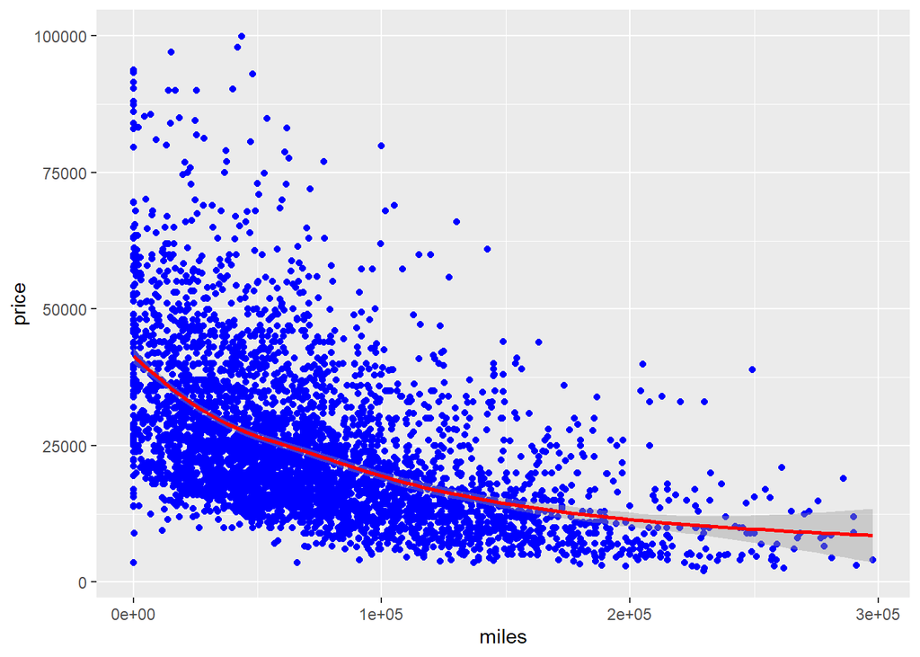

```r
# Price ~ miles
ggplot(data=samplecardata,mapping=aes(x=miles,y=price))+geom_point(col = "blue")+geom_smooth(col = "red")
```

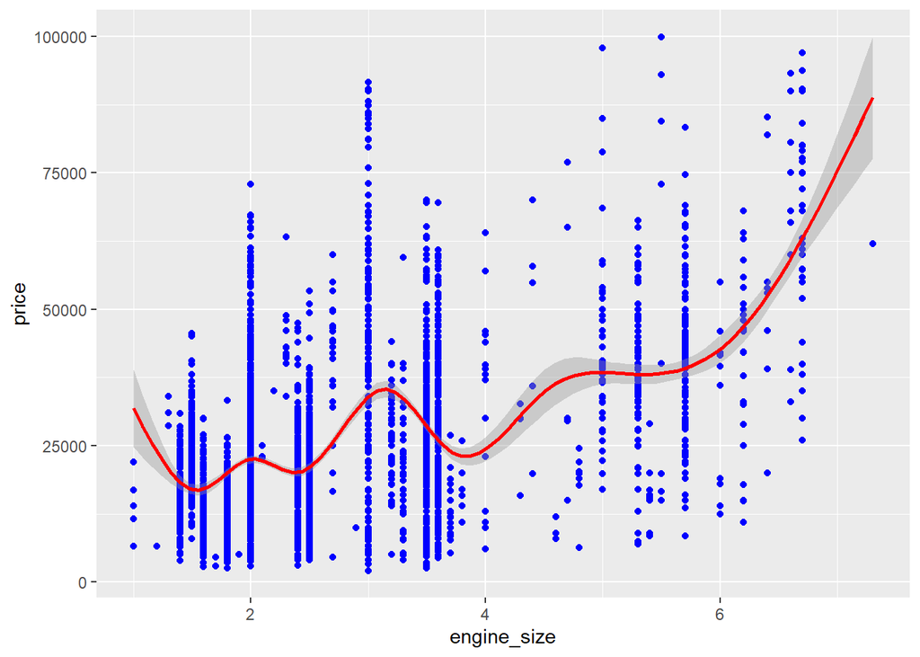

```r
# Price ~ engine_size
ggplot(data=samplecardata,mapping=aes(x=engine_size,y=price))+geom_point(col = "blue")+geom_smooth(col = "red")
```

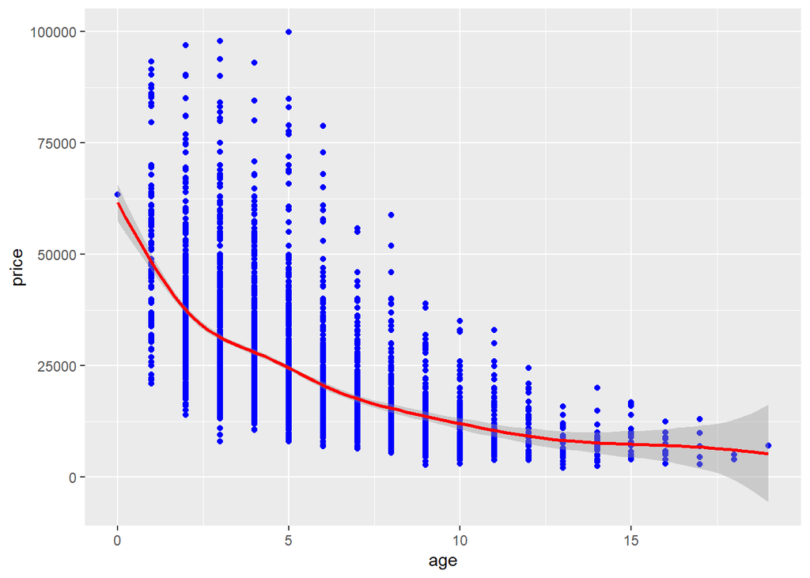

[figure not shown]

Relation between Price and quantitative variables in the model

```r
# Price ~ age
ggplot(data=samplecardata,mapping=aes(x=age,y=price))+geom_point(col = "blue")+geom_smooth(col = "red")
```

From the plotting above, we could observe a curve between the correlation of price and miles, indicating we should move to higher order of the miles.Also same behaviour observed for price and age, indicating we should move to higher order of the age Although the correlation between engine_size and price is fluctuation, the correlation line might be regarded as close to linear. So, we will keep the first order for engine_size predictor.

```r
Higher_order_1 = lm(price~poly(miles, 2, raw = T)+poly(age,2,raw = T)+engine_size+factor(drivetrain)+factor(transmission)+factor(make_body_type)+miles:age+miles:engine_size+miles:factor(drivetrain)+miles:factor(make_body_type)+age:engine_size+age:factor(drivetrain)+age:factor(make_body_type)+engine_size:factor(drivetrain)+engine_size:factor(transmission)+engine_size:factor(make_body_type)+factor(drivetrain):factor(transmission),data = samplecardata)
summary(Higher_order_1)
```

```
##
## Call:
## lm(formula = price ~ poly(miles, 2, raw = T) + poly(age, 2, raw = T) +
##     engine_size + factor(drivetrain) + factor(transmission) +
##     factor(make_body_type) + miles:age + miles:engine_size +
##     miles:factor(drivetrain) + miles:factor(make_body_type) +
##     age:engine_size + age:factor(drivetrain) + age:factor(make_body_type) +
##     engine_size:factor(drivetrain) + engine_size:factor(transmission) +
##     engine_size:factor(make_body_type) + factor(drivetrain):factor(transmission),
##     data = samplecardata)
##
## Residuals:
##    Min     1Q Median     3Q    Max
## -25652  -2326   -219   2058  40835
##
## Coefficients:
##                                                            Estimate Std. Error
## (Intercept)                                               5.255e+04  4.865e+03
## poly(miles, 2, raw = T)1                                 -4.008e-02  2.265e-02
## poly(miles, 2, raw = T)2                                 -4.485e-08  4.151e-08
## poly(age, 2, raw = T)1                                   -2.975e+03  4.741e+02
## poly(age, 2, raw = T)2                                    7.015e+01  1.476e+01
## engine_size                                               4.082e+02  1.641e+03
## factor(drivetrain)FWD                                    -1.816e+03  1.218e+03
## factor(drivetrain)RWD                                    -9.640e+02  6.606e+03
## factor(transmission)MANUAL                               -2.660e+03  1.619e+03
## factor(make_body_type)AUDI | SUV                         -2.799e+04  6.072e+03
## factor(make_body_type)BMW | SEDAN                        -1.957e+04  5.601e+03
## factor(make_body_type)BMW | SUV                          -2.375e+04  5.276e+03
## factor(make_body_type)BUICK | SUV                        -2.802e+04  5.629e+03
## factor(make_body_type)CHEVROLET | HATCHBACK              -4.372e+04  1.079e+04
## factor(make_body_type)CHEVROLET | PICKUP                 -3.364e+04  5.936e+03
## factor(make_body_type)CHEVROLET | SEDAN                  -2.866e+04  5.238e+03
## factor(make_body_type)CHEVROLET | SUV                    -2.939e+04  5.005e+03
## factor(make_body_type)CHRYSLER | SEDAN                   -3.309e+04  7.462e+03
## factor(make_body_type)DODGE | SUV                        -3.130e+04  5.753e+03
## factor(make_body_type)DODGE | VAN                        -4.406e+04  2.481e+04
## factor(make_body_type)FORD | PICKUP                      -1.381e+04  5.098e+03
## factor(make_body_type)FORD | SEDAN                       -2.612e+04  5.669e+03
## factor(make_body_type)FORD | SUV                         -2.514e+04  4.951e+03
```

[output cut: 347 more lines]

```
## engine_size:factor(make_body_type)SUBARU | SUV             4.137 3.60e-05 ***
## engine_size:factor(make_body_type)TOYOTA | HATCHBACK       2.927 0.003441 **
## engine_size:factor(make_body_type)TOYOTA | SEDAN           5.252 1.58e-07 ***
## engine_size:factor(make_body_type)TOYOTA | SUV             6.345 2.48e-10 ***
## engine_size:factor(make_body_type)VOLKSWAGEN | HATCHBACK   5.138 2.91e-07 ***
## engine_size:factor(make_body_type)VOLKSWAGEN | SEDAN       2.587 0.009716 **
## engine_size:factor(make_body_type)VOLKSWAGEN | SUV         4.710 2.56e-06 ***
## factor(drivetrain)FWD:factor(transmission)MANUAL          -3.771 0.000165 ***
## factor(drivetrain)RWD:factor(transmission)MANUAL          -0.191 0.848331
## ---
## Signif. codes:  0 '***' 0.001 '**' 0.01 '*' 0.05 '.' 0.1 ' ' 1
##
## Residual standard error: 4904 on 4055 degrees of freedom
## Multiple R-squared:  0.8871, Adjusted R-squared:  0.8818
## F-statistic: 169.4 on 188 and 4055 DF,  p-value: < 2.2e-16
```

```r
Higher_order_2 = lm(price~poly(miles, 3, raw = T)+poly(age, 3 ,raw = T)+engine_size+factor(drivetrain)+factor(transmission)+factor(make_body_type)+miles:age+miles:engine_size+miles:factor(drivetrain)+miles:factor(make_body_type)+age:engine_size+age:factor(drivetrain)+age:factor(make_body_type)+engine_size:factor(drivetrain)+engine_size:factor(transmission)+engine_size:factor(make_body_type)+factor(drivetrain):factor(transmission),data = samplecardata)
summary(Higher_order_2)
```

```
##
## Call:
## lm(formula = price ~ poly(miles, 3, raw = T) + poly(age, 3, raw = T) +
##     engine_size + factor(drivetrain) + factor(transmission) +
##     factor(make_body_type) + miles:age + miles:engine_size +
##     miles:factor(drivetrain) + miles:factor(make_body_type) +
##     age:engine_size + age:factor(drivetrain) + age:factor(make_body_type) +
##     engine_size:factor(drivetrain) + engine_size:factor(transmission) +
##     engine_size:factor(make_body_type) + factor(drivetrain):factor(transmission),
##     data = samplecardata)
##
## Residuals:
##    Min     1Q Median     3Q    Max
## -25740  -2314   -237   2069  40272
##
## Coefficients:
##                                                            Estimate Std. Error
## (Intercept)                                               5.333e+04  4.870e+03
## poly(miles, 3, raw = T)1                                 -4.498e-02  2.447e-02
## poly(miles, 3, raw = T)2                                  4.241e-08  1.120e-07
## poly(miles, 3, raw = T)3                                 -2.540e-13  2.923e-13
## poly(age, 3, raw = T)1                                   -3.532e+03  5.510e+02
## poly(age, 3, raw = T)2                                    1.560e+02  4.482e+01
## poly(age, 3, raw = T)3                                   -3.526e+00  1.693e+00
## engine_size                                               4.916e+02  1.640e+03
## factor(drivetrain)FWD                                    -1.608e+03  1.223e+03
## factor(drivetrain)RWD                                    -1.966e+03  6.611e+03
## factor(transmission)MANUAL                               -2.880e+03  1.620e+03
## factor(make_body_type)AUDI | SUV                         -2.767e+04  6.069e+03
## factor(make_body_type)BMW | SEDAN                        -1.945e+04  5.597e+03
## factor(make_body_type)BMW | SUV                          -2.357e+04  5.273e+03
## factor(make_body_type)BUICK | SUV                        -2.780e+04  5.626e+03
## factor(make_body_type)CHEVROLET | HATCHBACK              -4.359e+04  1.078e+04
## factor(make_body_type)CHEVROLET | PICKUP                 -3.366e+04  5.935e+03
## factor(make_body_type)CHEVROLET | SEDAN                  -2.828e+04  5.236e+03
## factor(make_body_type)CHEVROLET | SUV                    -2.919e+04  5.002e+03
## factor(make_body_type)CHRYSLER | SEDAN                   -3.317e+04  7.461e+03
## factor(make_body_type)DODGE | SUV                        -3.069e+04  5.754e+03
## factor(make_body_type)DODGE | VAN                        -4.534e+04  2.484e+04
## factor(make_body_type)FORD | PICKUP                      -1.369e+04  5.097e+03
```

[output cut: 351 more lines]

```
## engine_size:factor(make_body_type)SUBARU | SUV             3.982 6.94e-05 ***
## engine_size:factor(make_body_type)TOYOTA | HATCHBACK       2.855 0.004320 **
## engine_size:factor(make_body_type)TOYOTA | SEDAN           5.201 2.08e-07 ***
## engine_size:factor(make_body_type)TOYOTA | SUV             6.312 3.05e-10 ***
## engine_size:factor(make_body_type)VOLKSWAGEN | HATCHBACK   5.076 4.02e-07 ***
## engine_size:factor(make_body_type)VOLKSWAGEN | SEDAN       2.323 0.020242 *
## engine_size:factor(make_body_type)VOLKSWAGEN | SUV         4.656 3.32e-06 ***
## factor(drivetrain)FWD:factor(transmission)MANUAL          -3.693 0.000225 ***
## factor(drivetrain)RWD:factor(transmission)MANUAL          -0.007 0.994124
## ---
## Signif. codes:  0 '***' 0.001 '**' 0.01 '*' 0.05 '.' 0.1 ' ' 1
##
## Residual standard error: 4900 on 4053 degrees of freedom
## Multiple R-squared:  0.8873, Adjusted R-squared:  0.882
## F-statistic: 167.9 on 190 and 4053 DF,  p-value: < 2.2e-16
```

```r
Higher_order_3 = lm(price~poly(miles, 4, raw = T)+poly(age,4,raw = T)+engine_size+factor(drivetrain)+factor(transmission)+factor(make_body_type)+miles:age+miles:engine_size+miles:factor(drivetrain)+miles:factor(make_body_type)+age:engine_size+age:factor(drivetrain)+age:factor(make_body_type)+engine_size:factor(drivetrain)+engine_size:factor(transmission)+engine_size:factor(make_body_type)+factor(drivetrain):factor(transmission),data = samplecardata)
summary(Higher_order_3)
```

```
##
## Call:
## lm(formula = price ~ poly(miles, 4, raw = T) + poly(age, 4, raw = T) +
##     engine_size + factor(drivetrain) + factor(transmission) +
##     factor(make_body_type) + miles:age + miles:engine_size +
##     miles:factor(drivetrain) + miles:factor(make_body_type) +
##     age:engine_size + age:factor(drivetrain) + age:factor(make_body_type) +
##     engine_size:factor(drivetrain) + engine_size:factor(transmission) +
##     engine_size:factor(make_body_type) + factor(drivetrain):factor(transmission),
##     data = samplecardata)
##
## Residuals:
##    Min     1Q Median     3Q    Max
## -25900  -2320   -208   2065  39166
##
## Coefficients:
##                                                            Estimate Std. Error
## (Intercept)                                               5.588e+04  4.898e+03
## poly(miles, 4, raw = T)1                                 -6.314e-02  2.930e-02
## poly(miles, 4, raw = T)2                                  3.945e-07  3.116e-07
## poly(miles, 4, raw = T)3                                 -2.759e-12  1.857e-12
## poly(miles, 4, raw = T)4                                  5.339e-18  3.599e-18
## poly(age, 4, raw = T)1                                   -5.261e+03  7.603e+02
## poly(age, 4, raw = T)2                                    5.879e+02  1.359e+02
## poly(age, 4, raw = T)3                                   -4.321e+01  1.165e+01
## poly(age, 4, raw = T)4                                    1.189e+00  3.413e-01
## engine_size                                               3.256e+02  1.637e+03
## factor(drivetrain)FWD                                    -1.513e+03  1.221e+03
## factor(drivetrain)RWD                                    -3.451e+02  6.607e+03
## factor(transmission)MANUAL                               -3.117e+03  1.617e+03
## factor(make_body_type)AUDI | SUV                         -2.790e+04  6.057e+03
## factor(make_body_type)BMW | SEDAN                        -2.058e+04  5.591e+03
## factor(make_body_type)BMW | SUV                          -2.375e+04  5.262e+03
## factor(make_body_type)BUICK | SUV                        -2.782e+04  5.614e+03
## factor(make_body_type)CHEVROLET | HATCHBACK              -4.318e+04  1.076e+04
## factor(make_body_type)CHEVROLET | PICKUP                 -3.316e+04  5.923e+03
## factor(make_body_type)CHEVROLET | SEDAN                  -2.837e+04  5.224e+03
## factor(make_body_type)CHEVROLET | SUV                    -2.917e+04  4.991e+03
## factor(make_body_type)CHRYSLER | SEDAN                   -3.324e+04  7.447e+03
## factor(make_body_type)DODGE | SUV                        -3.092e+04  5.742e+03
```

[output cut: 355 more lines]

```
## engine_size:factor(make_body_type)SUBARU | SUV             3.787 0.000154 ***
## engine_size:factor(make_body_type)TOYOTA | HATCHBACK       2.895 0.003808 **
## engine_size:factor(make_body_type)TOYOTA | SEDAN           5.267 1.46e-07 ***
## engine_size:factor(make_body_type)TOYOTA | SUV             6.345 2.47e-10 ***
## engine_size:factor(make_body_type)VOLKSWAGEN | HATCHBACK   4.944 7.96e-07 ***
## engine_size:factor(make_body_type)VOLKSWAGEN | SEDAN       2.495 0.012625 *
## engine_size:factor(make_body_type)VOLKSWAGEN | SUV         4.689 2.83e-06 ***
## factor(drivetrain)FWD:factor(transmission)MANUAL          -3.587 0.000339 ***
## factor(drivetrain)RWD:factor(transmission)MANUAL          -0.334 0.738293
## ---
## Signif. codes:  0 '***' 0.001 '**' 0.01 '*' 0.05 '.' 0.1 ' ' 1
##
## Residual standard error: 4890 on 4051 degrees of freedom
## Multiple R-squared:  0.8878, Adjusted R-squared:  0.8825
## F-statistic:   167 on 192 and 4051 DF,  p-value: < 2.2e-16
```

```r
Higher_order_4 = lm(price~poly(miles, 5, raw = T)+poly(age,4,raw = T)+engine_size+factor(drivetrain)+factor(transmission)+factor(make_body_type)+miles:age+miles:engine_size+miles:factor(drivetrain)+miles:factor(make_body_type)+age:engine_size+age:factor(drivetrain)+age:factor(make_body_type)+engine_size:factor(drivetrain)+engine_size:factor(transmission)+engine_size:factor(make_body_type)+factor(drivetrain):factor(transmission),data = samplecardata)
summary(Higher_order_4)
```

```
##
## Call:
## lm(formula = price ~ poly(miles, 5, raw = T) + poly(age, 4, raw = T) +
##     engine_size + factor(drivetrain) + factor(transmission) +
##     factor(make_body_type) + miles:age + miles:engine_size +
##     miles:factor(drivetrain) + miles:factor(make_body_type) +
##     age:engine_size + age:factor(drivetrain) + age:factor(make_body_type) +
##     engine_size:factor(drivetrain) + engine_size:factor(transmission) +
##     engine_size:factor(make_body_type) + factor(drivetrain):factor(transmission),
##     data = samplecardata)
##
## Residuals:
##    Min     1Q Median     3Q    Max
## -25716  -2313   -204   2065  38843
##
## Coefficients:
##                                                            Estimate Std. Error
## (Intercept)                                               5.637e+04  4.897e+03
## poly(miles, 5, raw = T)1                                 -1.243e-01  3.664e-02
## poly(miles, 5, raw = T)2                                  2.095e-06  6.871e-07
## poly(miles, 5, raw = T)3                                 -2.091e-11  6.796e-12
## poly(miles, 5, raw = T)4                                  8.535e-17  2.905e-17
## poly(miles, 5, raw = T)5                                 -1.229e-22  4.427e-23
## poly(age, 4, raw = T)1                                   -5.098e+03  7.619e+02
## poly(age, 4, raw = T)2                                    5.556e+02  1.362e+02
## poly(age, 4, raw = T)3                                   -4.096e+01  1.167e+01
## poly(age, 4, raw = T)4                                    1.137e+00  3.416e-01
## engine_size                                               2.734e+02  1.636e+03
## factor(drivetrain)FWD                                    -1.549e+03  1.220e+03
## factor(drivetrain)RWD                                    -7.330e+02  6.603e+03
## factor(transmission)MANUAL                               -3.079e+03  1.616e+03
## factor(make_body_type)AUDI | SUV                         -2.831e+04  6.054e+03
## factor(make_body_type)BMW | SEDAN                        -2.104e+04  5.589e+03
## factor(make_body_type)BMW | SUV                          -2.405e+04  5.259e+03
## factor(make_body_type)BUICK | SUV                        -2.797e+04  5.610e+03
## factor(make_body_type)CHEVROLET | HATCHBACK              -4.338e+04  1.075e+04
## factor(make_body_type)CHEVROLET | PICKUP                 -3.321e+04  5.918e+03
## factor(make_body_type)CHEVROLET | SEDAN                  -2.858e+04  5.221e+03
## factor(make_body_type)CHEVROLET | SUV                    -2.935e+04  4.987e+03
## factor(make_body_type)CHRYSLER | SEDAN                   -3.403e+04  7.447e+03
```

[output cut: 357 more lines]

```
## engine_size:factor(make_body_type)SUBARU | SUV             3.808 0.000142 ***
## engine_size:factor(make_body_type)TOYOTA | HATCHBACK       2.923 0.003491 **
## engine_size:factor(make_body_type)TOYOTA | SEDAN           5.330 1.03e-07 ***
## engine_size:factor(make_body_type)TOYOTA | SUV             6.410 1.62e-10 ***
## engine_size:factor(make_body_type)VOLKSWAGEN | HATCHBACK   4.864 1.20e-06 ***
## engine_size:factor(make_body_type)VOLKSWAGEN | SEDAN       2.552 0.010736 *
## engine_size:factor(make_body_type)VOLKSWAGEN | SUV         4.712 2.53e-06 ***
## factor(drivetrain)FWD:factor(transmission)MANUAL          -3.602 0.000319 ***
## factor(drivetrain)RWD:factor(transmission)MANUAL          -0.390 0.696351
## ---
## Signif. codes:  0 '***' 0.001 '**' 0.01 '*' 0.05 '.' 0.1 ' ' 1
##
## Residual standard error: 4886 on 4050 degrees of freedom
## Multiple R-squared:  0.8881, Adjusted R-squared:  0.8827
## F-statistic: 166.5 on 193 and 4050 DF,  p-value: < 2.2e-16
```

### 2.1.4 Exponential Transformation on predictors on Miles and Age

We have applied exponential transformation on $miles = exp(-miles/100000)$ and $Age = exp(-age/5)$

```r
samplecardata = samplecardata %>% mutate(age_exp = exp(-age/5), miles_exp = exp(-miles/100000))
```

```r
Final_suggested_model_exp = lm(price~miles_exp+age_exp+engine_size+factor(drivetrain)+factor(transmission)+factor(make_body_type)+miles_exp:age_exp+miles_exp:engine_size+miles_exp:factor(drivetrain)+miles_exp:factor(make_body_type)+age_exp:engine_size+age_exp:factor(drivetrain)+age_exp:factor(make_body_type)+engine_size:factor(drivetrain)+engine_size:factor(transmission)+engine_size:factor(make_body_type)+factor(drivetrain):factor(transmission),data = samplecardata)
summary(Final_suggested_model_exp)
```

```
##
## Call:
## lm(formula = price ~ miles_exp + age_exp + engine_size + factor(drivetrain) +
##     factor(transmission) + factor(make_body_type) + miles_exp:age_exp +
##     miles_exp:engine_size + miles_exp:factor(drivetrain) + miles_exp:factor(make_body_type) +
##     age_exp:engine_size + age_exp:factor(drivetrain) + age_exp:factor(make_body_type) +
##     engine_size:factor(drivetrain) + engine_size:factor(transmission) +
##     engine_size:factor(make_body_type) + factor(drivetrain):factor(transmission),
##     data = samplecardata)
##
## Residuals:
##    Min     1Q Median     3Q    Max
## -28254  -2208   -269   1959  43062
##
## Coefficients:
##                                                          Estimate Std. Error
## (Intercept)                                               24301.6     7297.3
## miles_exp                                                   452.9     6674.3
## age_exp                                                   42448.7     8661.8
## engine_size                                               -5790.3     1796.7
## factor(drivetrain)FWD                                      4695.4     1666.5
## factor(drivetrain)RWD                                      4453.0     4626.0
## factor(transmission)MANUAL                                -3162.0     1644.3
## factor(make_body_type)AUDI | SUV                         -45506.9     9066.2
## factor(make_body_type)BMW | SEDAN                        -37682.4     8039.9
## factor(make_body_type)BMW | SUV                          -50849.2     7732.1
## factor(make_body_type)BUICK | SUV                        -23220.2     7981.6
## factor(make_body_type)CHEVROLET | HATCHBACK              -36426.0    13960.0
## factor(make_body_type)CHEVROLET | PICKUP                 -26666.5     7981.7
## factor(make_body_type)CHEVROLET | SEDAN                  -27336.3     7612.3
## factor(make_body_type)CHEVROLET | SUV                    -28264.7     7365.2
## factor(make_body_type)CHRYSLER | SEDAN                   -24551.0     9164.0
## factor(make_body_type)DODGE | SUV                        -25765.6     7579.9
## factor(make_body_type)DODGE | VAN                        -22333.7    24578.8
## factor(make_body_type)FORD | PICKUP                      -19604.3     7377.5
## factor(make_body_type)FORD | SEDAN                       -23401.3     7955.3
## factor(make_body_type)FORD | SUV                         -28788.2     7323.3
## factor(make_body_type)GMC | PICKUP                       -31568.3     8611.6
## factor(make_body_type)GMC | SUV                          -32026.7     7676.5
## factor(make_body_type)HONDA | SEDAN                      -17485.1     8040.1
```

[output cut: 342 more lines]

```
## engine_size:factor(make_body_type)SUBARU | SUV             3.755 0.000176 ***
## engine_size:factor(make_body_type)TOYOTA | HATCHBACK       2.786 0.005359 **
## engine_size:factor(make_body_type)TOYOTA | SEDAN           4.777 1.84e-06 ***
## engine_size:factor(make_body_type)TOYOTA | SUV             5.642 1.80e-08 ***
## engine_size:factor(make_body_type)VOLKSWAGEN | HATCHBACK   5.001 5.94e-07 ***
## engine_size:factor(make_body_type)VOLKSWAGEN | SEDAN       2.340 0.019355 *
## engine_size:factor(make_body_type)VOLKSWAGEN | SUV         3.837 0.000126 ***
## factor(drivetrain)FWD:factor(transmission)MANUAL          -2.912 0.003616 **
## factor(drivetrain)RWD:factor(transmission)MANUAL          -1.135 0.256257
## ---
## Signif. codes:  0 '***' 0.001 '**' 0.01 '*' 0.05 '.' 0.1 ' ' 1
##
## Residual standard error: 4977 on 4057 degrees of freedom
## Multiple R-squared:  0.8836, Adjusted R-squared:  0.8783
## F-statistic: 165.6 on 186 and 4057 DF,  p-value: < 2.2e-16
```

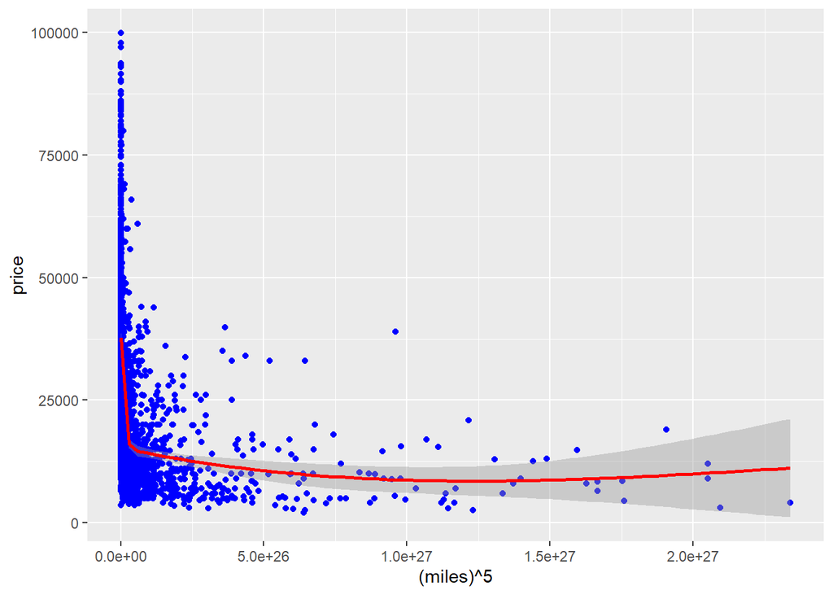

```r
# Price ~ miles
ggplot(data=samplecardata,mapping=aes(x=(miles)^5,y=price))+geom_point(col = "blue")+geom_smooth(col = "red")
```

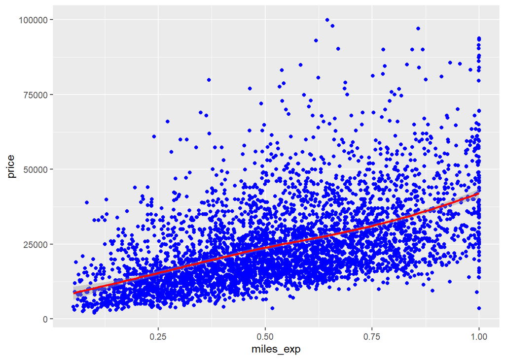

[figure not shown]

Fig comparing “Miles” Highorder vs Exponentia transformation

```r
ggplot(data=samplecardata,mapping=aes(x=miles_exp,y=price))+geom_point(col = "blue")+geom_smooth(col = "red")
```

Regarding the predictor miles, we compared the miles at the 5th order and the exponential value by plotting the correlation with price. From the plotting above, the exponential transformation line might fit the points better.

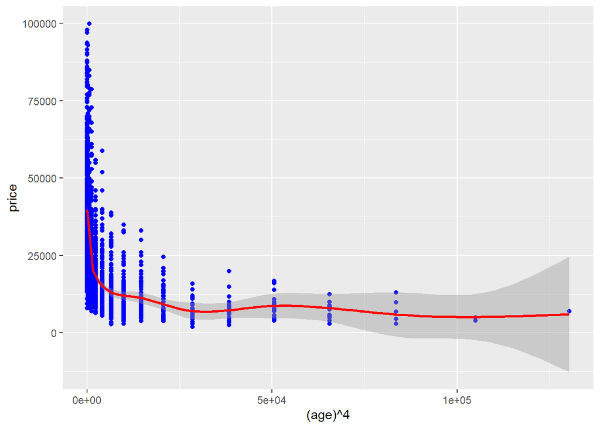

```r
# Price ~ age
ggplot(data=samplecardata,mapping=aes(x=(age)^4,y=price))+geom_point(col = "blue")+geom_smooth(col = "red")
```

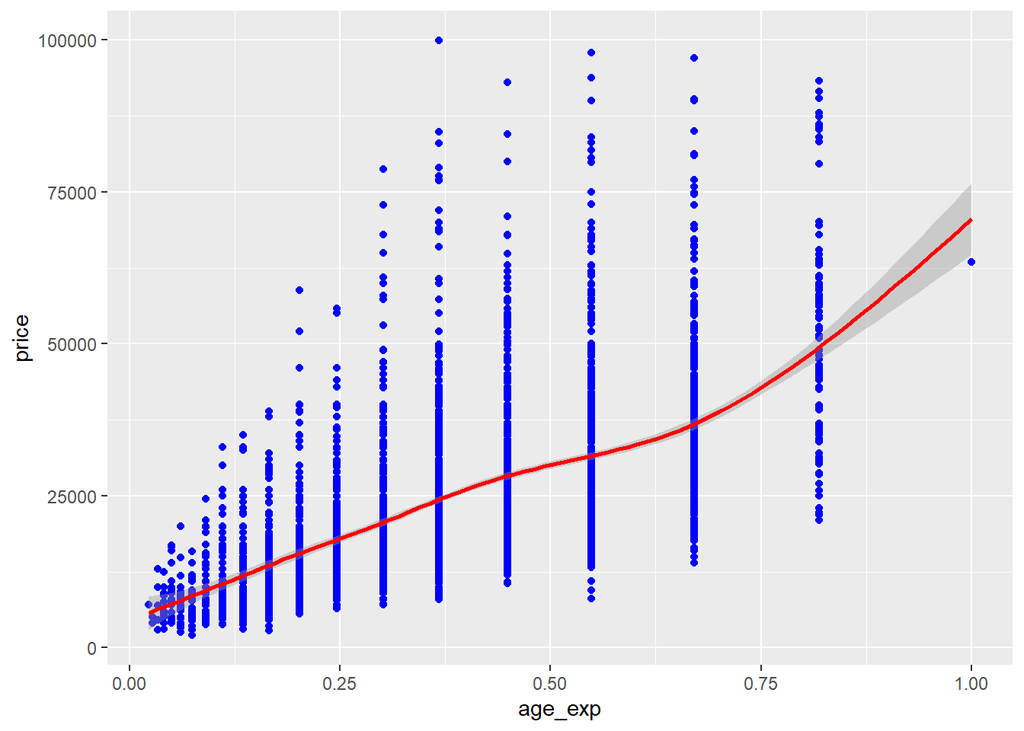

[figure not shown]

Fig comparing “Age” Highorder vs Exponentia transformation

```r
ggplot(data=samplecardata,mapping=aes(x=age_exp,y=price))+geom_point(col = "blue")+geom_smooth(col = "red")
```

Regarding the predictor age, we compared the miles at the 4th order and the exponential value by plotting the correlation with price. From the plotting above, the exponential transformation line might fit the points better.

Therefore, we will apply the exponential value of age and miles in the model.

The estimated model is
$$\begin {aligned}
\hat{Price}_{i}=\beta_{0}+\beta_{i}exp(-miles/1e+05)+\beta_{i}exp(-age/5)+\\
\beta_{i}engine.size+\beta_{i1}drivetrain+\beta_{i2}transmission+\\
\beta_{i3}make.body.type+\beta_{i}exp(-miles/1e+05)*exp(-age/5)+\\
\beta_{i}exp(-miles/1e+05)*engine.size+\beta_{i4}exp(-miles/1e+05)*drivetrain+\\
\beta_{i5}exp(-miles/1e+05)*make.body.type+\beta_{i}exp(-age/5)*engine.size+\\
\beta_{i6}exp(-age/5)*drivetrain+\beta_{i7}exp(-age/5)*make.body.type+\\
\beta_{i8}engine.size*drivetrain+\beta_{i9}engine.size*transmission+\\
\beta_{i10}engine.size*make.body.type+\beta_{i11}drivetrain*transmission
\end {aligned}$$

## 2.2 Regresion Model Diagnostics

### 2.2.1 Before the transformation.

#### 2.2.1.1 1. Linearity Assumption.

The residual plot for the selected final regression model was plotted against the fitted used car price to identify any non-linearity.

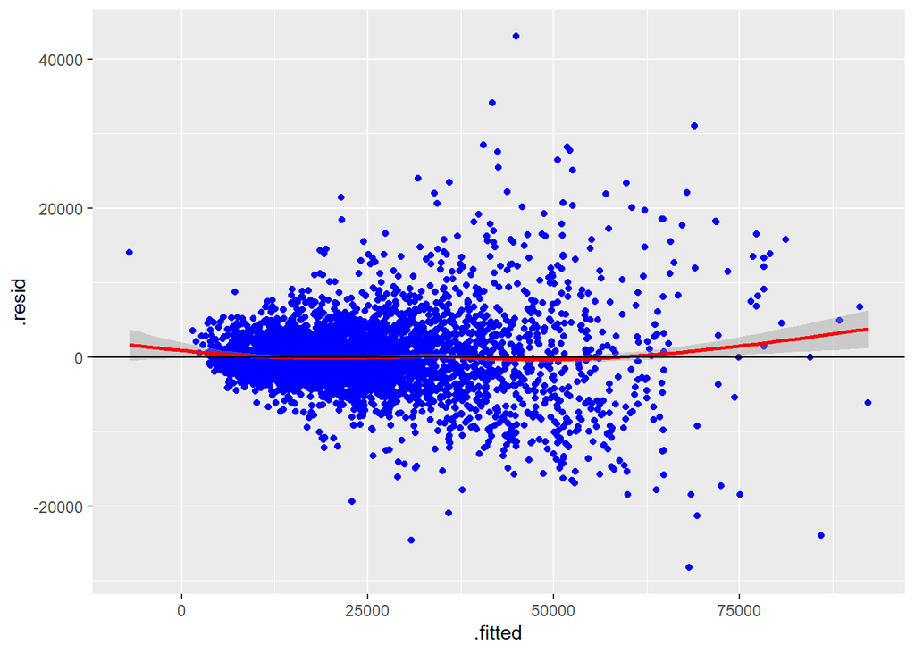

```
                            [Linearity Assumption verification]
```

```r
ggplot(Final_suggested_model_exp, aes(x=.fitted,y=.resid))+geom_point(col = "blue")+geom_smooth(col = "red")+geom_hline(yintercept = 0)
```

#### 2.2.1.2 2. Independence Assumption

In order to confirm the uncorrected error terms amount the data for both dependent and independent variables, We check displays of the regression residual for evidence of patterns, trends or clumping to identify independence.

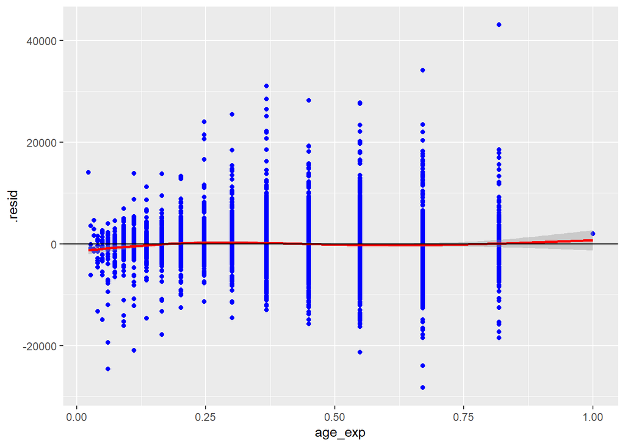

```
                             [Independence Assumption verification]
```

```r
ggplot(Final_suggested_model_exp, aes(x=age_exp,y=.resid))+geom_point(col = "blue")+geom_smooth(col = "red")+geom_hline(yintercept = 0)
```

From the plot, a perceptible funnel pattern was observed. The assumption of independent errors is violated due to the successive errors are correlated. After further study the exponentially transformed age data, we concluded that the violation of the independence assumption of the final model is due to the data for both dependent and independent variables are time-series data. A further corrective measure is warranted.

#### 2.2.1.3 3. Equal Variance Assumption

The next step we need to confirm the error terms are homoscedasticity.

We plotted the spread of the residual over the range of fitted value predicted by our final regression model and showed as follow.

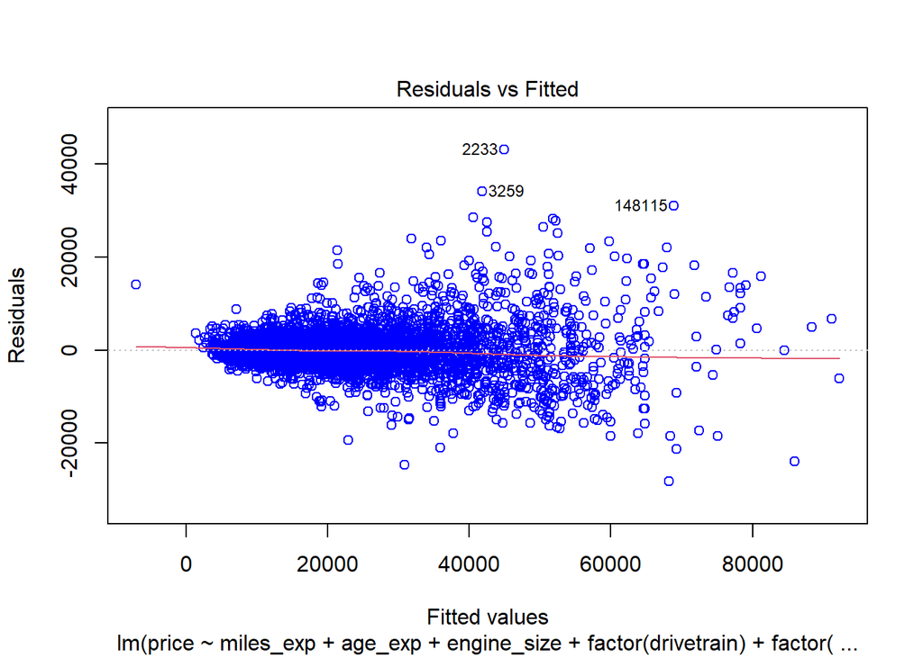

```
                       [Equal variance Assumption verification]
```

```r
plot(Final_suggested_model_exp, which=1, col = "blue")
```

The plot showed the magnitude of the residuals tends to increase or decrease with the fitted values. To further confirm the sample residuals may be heteroscedasticity, a formal detection of heteroscedasticity was conducted by performing the Breusch-Pagan test.

$$\begin{aligned}
H_0:&\mbox{ the sample residuals are homoscedasticity}\\
H_a~:&\mbox{ the sample residuals are heteroscedasticity} \\
\end{aligned}$$

```r
bptest(Final_suggested_model_exp)
```

```
##
##  studentized Breusch-Pagan test
##
## data:  Final_suggested_model_exp
## BP = 1143.2, df = 186, p-value < 2.2e-16
```

The output of the Breusch-Pagan test displayed a extremly small P-value. This indicated that we should reject the null hypothesis. Therefore, the test provided the evidence that heteroscedasticity does exist in the sample residual. A further corrective measure is warranted.

#### 2.2.1.4 4. Normality Assumption

Furthermore, we need to confirm the errors between observed and predicted values are normally distributed.

We first checked this assumption by looking at the residual histogram and a normal probability plot (Q-Q plot) below:

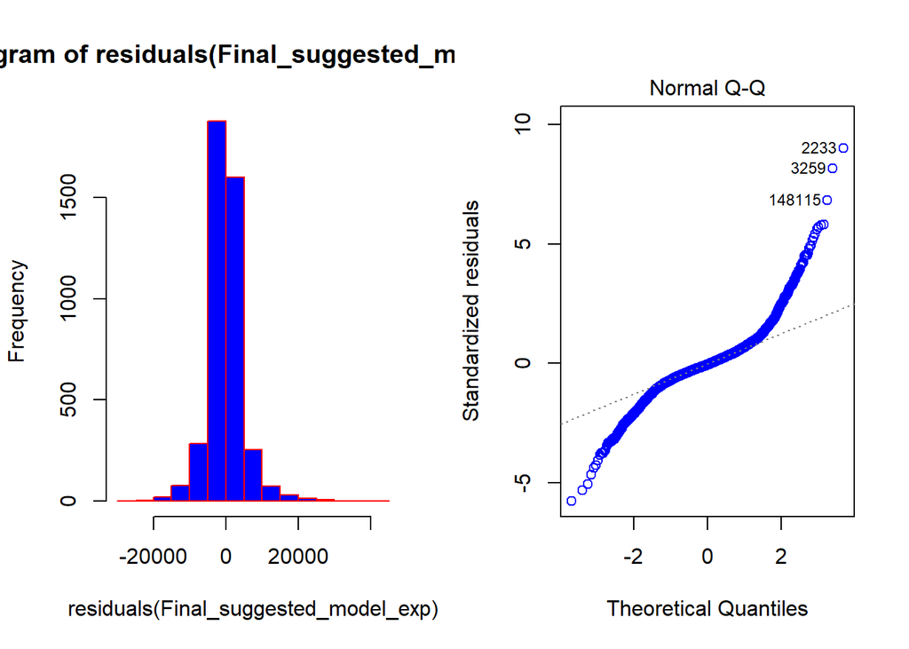

```
                            [Normality Assumption verification]
```

```r
par(mfrow=c(1,2))
hist(residuals(Final_suggested_model_exp), col = "blue", border = "red")
plot(Final_suggested_model_exp,which=2, col = "blue", border = "red")
```

$$\begin{aligned}
H_0:&\mbox{ the sample residuals are normally distributed}\\
H_a~:&\mbox{ the sample residuals are non-normally distributed} \\
\end{aligned}$$
Both plot showed the residue distributions are not normally distributed. The Q-Q plot significantly deviated from the straight diagnal line. Strong non-normality was observed. The conclusion is further confirmed by Shapiro-Wilk normality test.

```r
shapiro.test(residuals(Final_suggested_model_exp))
```

```
##
##  Shapiro-Wilk normality test
##
## data:  residuals(Final_suggested_model_exp)
## W = 0.90477, p-value < 2.2e-16
```

Shapiro-Wilk normality test confirmed the residuals are not normally distributed as the p-value = 2.2e-16 <0.05. The null hypothesis should be rejected. Therefore the alternative hypothesis is in favor which indicated the data are not normally distributed.

#### 2.2.1.5 5. Outlier - The effect on Individual Cases.

For random sampling data, outliers are almost always exist. However, not all outliers are influential in linear regression. We first check our sample data outliers by plotting Leverage points against 2p/n and 3p/n benchmark line as follow:

```r
le <- hatvalues(Final_suggested_model_exp)
p <- length(coef(Final_suggested_model_exp))
n <- nrow(samplecardata)
outlier2p = le[le>(2*p/n)]
outlier3p = le[le>(3*p/n)]
```

```r
length(outlier2p)
```

```
## [1] 453
```

```r
length(outlier3p)
```

```
## [1] 184
```

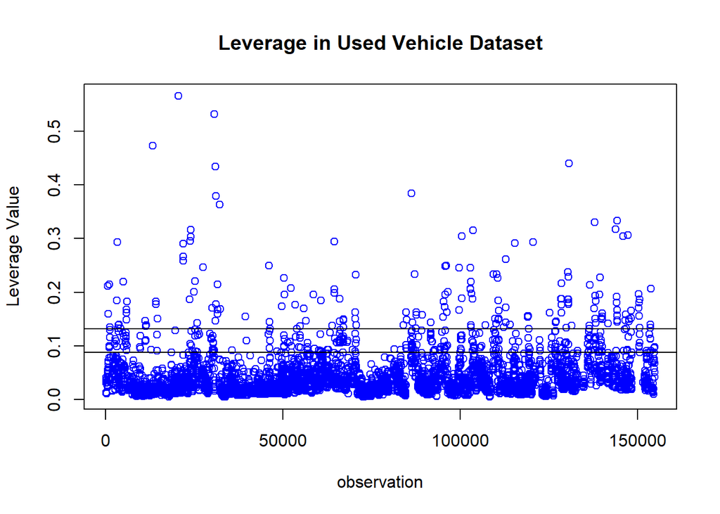

```
               [Influential Observation on least square slope verification]
```

```r
plot(rownames(samplecardata),le, main = "Leverage in Used Vehicle Dataset", xlab="observation",
ylab = "Leverage Value",col = "blue")
abline(h = 2 *p/n, lty = 1)
abline(h = 3 *p/n, lty = 1)
```

The plot showed significant sample data are above 3p/n line. This triggered us to further identify any influential outliers in the overall data set. A residuals vs leverage plot with cook’s distance plot was used to identify influential outliers:

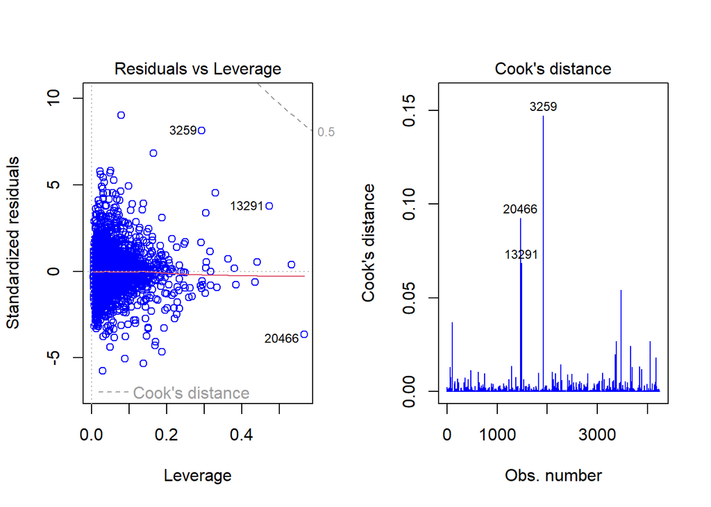

```
                          [Influential outliers verification]
```

```r
par(mfrow=c(1,2))
plot(Final_suggested_model_exp,col = "Blue",which = 5)
plot(Final_suggested_model_exp,pch = 18, col = "Blue",which = 4)
```

```r
samplecardata[cooks.distance(Final_suggested_model_exp)>0.5,]
```

| vin | price | miles | make | body_type | vehicle_type | drivetrain | transmission | engine_size | age | make_model | make_body_type | make_model_body_type | RowNum | age_exp | miles_exp |
| --- | --- | --- | --- | --- | --- | --- | --- | --- | --- | --- | --- | --- | --- | --- | --- |

The result showed most of the outliers came with significantly small Cook’s distance scores. This indicated that the outliers are not influential to the regression result. The final regression model past the influential outlier check. The above plot indicated no outliers which are influential in the linear regression analysis, as we observed no data point showed at the upper and lower right corner of the plot.

#### 2.2.1.6 6. Multicollinearity

We had been checking model multicollinearity along the way of developing the model. The redundancy of the independent variables in the following section by observing pair plot and evaluating the Variance Inflation Factors (VIF).

```r
reducedfomodel1 = lm(price~miles_exp+age_exp+engine_size+factor(drivetrain)+factor(transmission)+factor(make_body_type),data = samplecardata)
library(mctest)
imcdiag(reducedfomodel1,method="VIF")
```

```
##
## Call:
## imcdiag(mod = reducedfomodel1, method = "VIF")
##
##
##  VIF Multicollinearity Diagnostics
##
##                                                 VIF detection
## miles_exp                                    2.9661         0
## age_exp                                      3.0436         0
## engine_size                                  3.0149         0
## factor(drivetrain)FWD                        3.7791         0
## factor(drivetrain)RWD                        1.0992         0
## factor(transmission)MANUAL                   1.1623         0
## factor(make_body_type)AUDI | SUV             2.0754         0
## factor(make_body_type)BMW | SEDAN            2.7420         0
## factor(make_body_type)BMW | SUV              3.4735         0
## factor(make_body_type)BUICK | SUV            1.9991         0
## factor(make_body_type)CHEVROLET | HATCHBACK  2.3946         0
## factor(make_body_type)CHEVROLET | PICKUP     2.8782         0
## factor(make_body_type)CHEVROLET | SEDAN      4.2123         0
## factor(make_body_type)CHEVROLET | SUV        4.1776         0
## factor(make_body_type)CHRYSLER | SEDAN       1.8417         0
## factor(make_body_type)DODGE | SUV            2.6624         0
## factor(make_body_type)DODGE | VAN            4.0960         0
## factor(make_body_type)FORD | PICKUP          4.2553         0
## factor(make_body_type)FORD | SEDAN           2.8833         0
## factor(make_body_type)FORD | SUV             7.2558         0
## factor(make_body_type)GMC | PICKUP           2.7290         0
## factor(make_body_type)GMC | SUV              2.4496         0
## factor(make_body_type)HONDA | SEDAN          5.1877         0
## factor(make_body_type)HONDA | SUV            4.8440         0
## factor(make_body_type)HYUNDAI | HATCHBACK    1.8887         0
## factor(make_body_type)HYUNDAI | SEDAN        4.5976         0
## factor(make_body_type)HYUNDAI | SUV          5.3496         0
## factor(make_body_type)JEEP | SUV             5.8072         0
## factor(make_body_type)KIA | HATCHBACK        2.8534         0
## factor(make_body_type)KIA | SEDAN            3.3221         0
## factor(make_body_type)KIA | SUV              3.4912         0
## factor(make_body_type)LAND_ROVER | SUV       1.9392         0
```

[output cut: 8 more lines]

```
## factor(make_body_type)RAM | PICKUP           5.1093         0
## factor(make_body_type)SUBARU | SUV           1.9160         0
## factor(make_body_type)TOYOTA | HATCHBACK     2.2147         0
## factor(make_body_type)TOYOTA | SEDAN         5.0458         0
## factor(make_body_type)TOYOTA | SUV           4.5854         0
## factor(make_body_type)VOLKSWAGEN | HATCHBACK 1.9510         0
## factor(make_body_type)VOLKSWAGEN | SEDAN     3.3897         0
## factor(make_body_type)VOLKSWAGEN | SUV       2.4518         0
##
## NOTE:  VIF Method Failed to detect multicollinearity
##
##
## 0 --> COLLINEARITY is not detected by the test
##
## ===================================
```

[figure not shown]

Most of the test VIF value are between 1 and 5, which indicated moderate collinearity and not warrant a corrective action. The multicollinearity assumption of the final model is considered valid.

### 2.2.2 Box-Cox Transformation(To fix Non-normallity and Heteroscedasticity).

Verifying if the response variable has all response values is positive and greater than 0

```r
estimatedvalues <- Final_suggested_model_exp$fitted.values
residualsvalues <- Final_suggested_model_exp$residuals
df = data.frame(cbind(estimatedvalues,residualsvalues))
filter(df, estimatedvalues <= 0)
```

|  | estimatedvalues | residualsvalues |
| --- | --- | --- |
| 145936 | -7038.228 | 14037.23 |

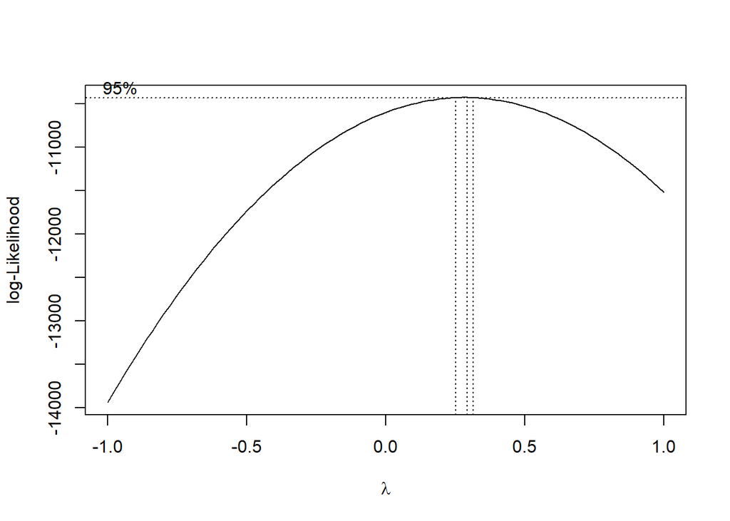

```r
bct <- boxcox(Final_suggested_model_exp, lambda = seq(-1,1))
```

```r
boxtransf <- bct$x[which(bct$y == max(bct$y))]
boxtransf
```

```
## [1] 0.2929293
```

```r
#if lambda = box-cox transformed value
Final_suggested_modelfix1 = lm(((((price)^boxtransf)-1)/boxtransf)~miles_exp+age_exp+engine_size+factor(drivetrain)+factor(transmission)+factor(make_body_type)+miles_exp:age_exp+miles_exp:engine_size+miles_exp:factor(drivetrain)+miles_exp:factor(make_body_type)+age_exp:engine_size+age_exp:factor(drivetrain)+age_exp:factor(make_body_type)+engine_size:factor(drivetrain)+engine_size:factor(transmission)+engine_size:factor(make_body_type)+factor(drivetrain):factor(transmission),data = samplecardata)
summary(Final_suggested_modelfix1)
```

```
##
## Call:
## lm(formula = ((((price)^boxtransf) - 1)/boxtransf) ~ miles_exp +
##     age_exp + engine_size + factor(drivetrain) + factor(transmission) +
##     factor(make_body_type) + miles_exp:age_exp + miles_exp:engine_size +
##     miles_exp:factor(drivetrain) + miles_exp:factor(make_body_type) +
##     age_exp:engine_size + age_exp:factor(drivetrain) + age_exp:factor(make_body_type) +
##     engine_size:factor(drivetrain) + engine_size:factor(transmission) +
##     engine_size:factor(make_body_type) + factor(drivetrain):factor(transmission),
##     data = samplecardata)
##
## Residuals:
##      Min       1Q   Median       3Q      Max
## -27.7699  -1.9909  -0.0817   1.9626  18.7326
##
## Coefficients:
##                                                          Estimate Std. Error
## (Intercept)                                               46.4956     4.9995
## miles_exp                                                 17.7883     4.5726
## age_exp                                                   51.8633     5.9343
## engine_size                                               -1.4407     1.2310
## factor(drivetrain)FWD                                      1.2551     1.1417
## factor(drivetrain)RWD                                     -2.7308     3.1693
## factor(transmission)MANUAL                                -1.2746     1.1265
## factor(make_body_type)AUDI | SUV                         -23.3701     6.2114
## factor(make_body_type)BMW | SEDAN                        -17.7176     5.5082
## factor(make_body_type)BMW | SUV                          -20.0953     5.2974
## factor(make_body_type)BUICK | SUV                        -13.0825     5.4682
## factor(make_body_type)CHEVROLET | HATCHBACK              -31.4046     9.5642
## factor(make_body_type)CHEVROLET | PICKUP                  -9.5871     5.4683
## factor(make_body_type)CHEVROLET | SEDAN                  -19.5767     5.2153
## factor(make_body_type)CHEVROLET | SUV                    -17.6140     5.0460
## factor(make_body_type)CHRYSLER | SEDAN                   -19.7945     6.2784
## factor(make_body_type)DODGE | SUV                        -19.3584     5.1931
## factor(make_body_type)DODGE | VAN                        -24.8340    16.8392
## factor(make_body_type)FORD | PICKUP                       -4.4539     5.0544
## factor(make_body_type)FORD | SEDAN                       -17.3956     5.4503
## factor(make_body_type)FORD | SUV                         -17.7436     5.0173
## factor(make_body_type)GMC | PICKUP                       -11.6293     5.8999
## factor(make_body_type)GMC | SUV                          -19.2962     5.2592
```

[output cut: 343 more lines]

```
## engine_size:factor(make_body_type)SUBARU | SUV             3.677 0.000239 ***
## engine_size:factor(make_body_type)TOYOTA | HATCHBACK       3.604 0.000317 ***
## engine_size:factor(make_body_type)TOYOTA | SEDAN           5.145 2.81e-07 ***
## engine_size:factor(make_body_type)TOYOTA | SUV             4.848 1.30e-06 ***
## engine_size:factor(make_body_type)VOLKSWAGEN | HATCHBACK   5.276 1.39e-07 ***
## engine_size:factor(make_body_type)VOLKSWAGEN | SEDAN       2.134 0.032912 *
## engine_size:factor(make_body_type)VOLKSWAGEN | SUV         3.248 0.001172 **
## factor(drivetrain)FWD:factor(transmission)MANUAL          -4.210 2.61e-05 ***
## factor(drivetrain)RWD:factor(transmission)MANUAL          -1.343 0.179317
## ---
## Signif. codes:  0 '***' 0.001 '**' 0.01 '*' 0.05 '.' 0.1 ' ' 1
##
## Residual standard error: 3.41 on 4057 degrees of freedom
## Multiple R-squared:  0.9028, Adjusted R-squared:  0.8983
## F-statistic: 202.5 on 186 and 4057 DF,  p-value: < 2.2e-16
```

$$\begin {aligned}
(\hat{Price}_{i})^{0.2929293}=\beta_{0}+\beta_{i}exp(-miles/1e+05)+\beta_{i}exp(-age/5)+\\
\beta_{i}engine.size+\beta_{i1}drivetrain+\beta_{i2}transmission+\\
\beta_{i3}make.body.type+\beta_{i}exp(-miles/1e+05)*exp(-age/5)+\\
\beta_{i}exp(-miles/1e+05)*engine.size+\beta_{i4}exp(-miles/1e+05)*drivetrain+\\
\beta_{i5}exp(-miles/1e+05)*make.body.type+\beta_{i}exp(-age/5)*engine.size+\\
\beta_{i6}exp(-age/5)*drivetrain+\beta_{i7}exp(-age/5)*make.body.type+\\
\beta_{i8}engine.size*drivetrain+\beta_{i9}engine.size*transmission+\\
\beta_{i10}engine.size*make.body.type+\beta_{i11}drivetrain*transmission
\end {aligned}$$

### 2.2.3 After transformation

After the box-cox transformation, we did the regression diagnostic again to check if the 6 assumptions are met.

For comparison purpose, we plot the residual for both before and after the transformation.

#### 2.2.3.1 1. Independence Assumption

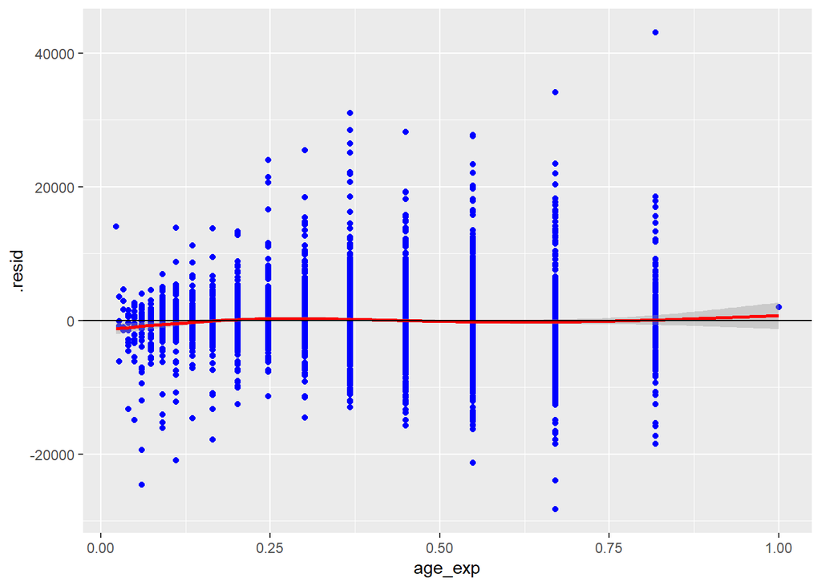

```r
ggplot(Final_suggested_model_exp, aes(x=age_exp,y=.resid))+geom_point(col = "blue")+geom_smooth(col = "red")+geom_hline(yintercept = 0)
```

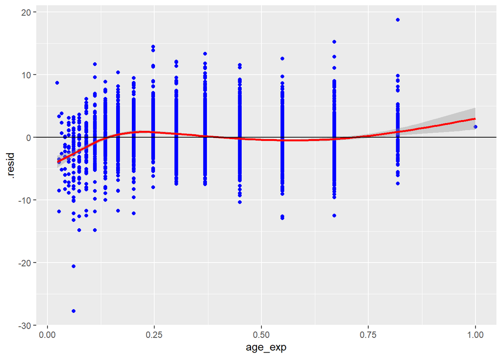

[figure not shown]

```r
ggplot(Final_suggested_modelfix1, aes(x=age_exp,y=.resid))+geom_point(col = "blue")+geom_smooth(col = "red")+geom_hline(yintercept = 0)
```

[Independence assumption verification comparing before(left) and after(right) box-cox transformation]

In order to confirm the uncorrected error terms, amount the data for both dependent and independent variables, we check displays of the regression residual for evidence of patterns, trends or clumping to identify independence after the transformation. The pattern after the transformation is not perfect distributed, but it is more even distributed after the transformation, indicating the independence increased

#### 2.2.3.2 2. Equal Variance Assumption

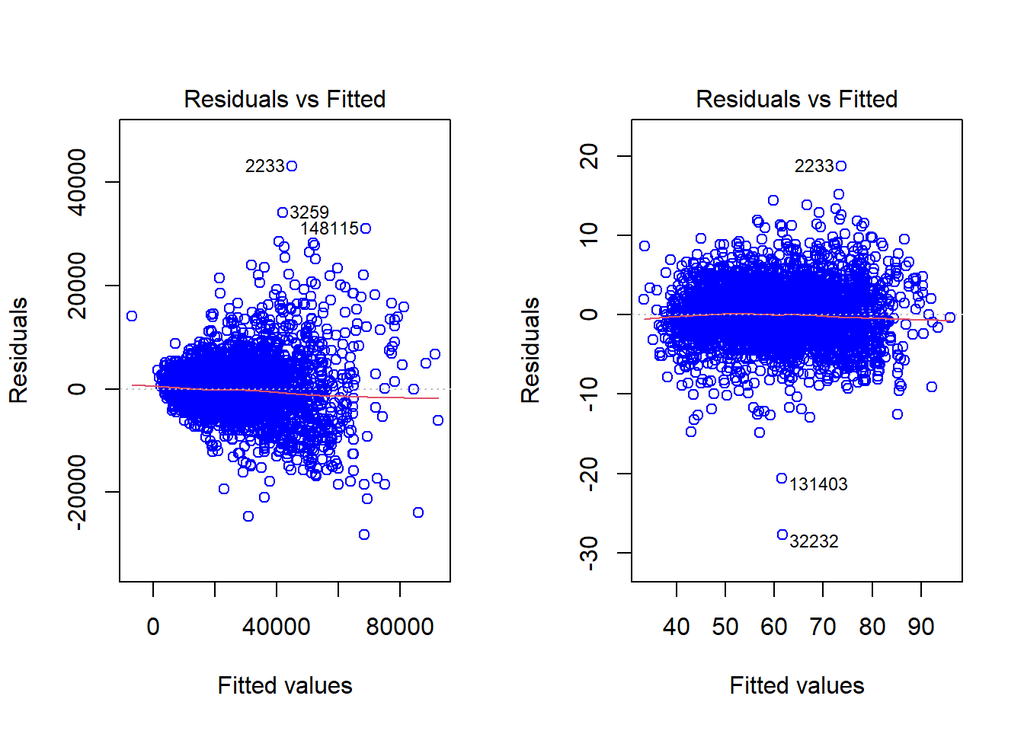

```r
par(mfrow= c(1,2))
plot(Final_suggested_model_exp, which=1,col = "blue")
plot(Final_suggested_modelfix1, which=1,col = "blue")
```

[Equal variance assumption verification comparing before(left) and after(right) box-cox transformation]

$$\begin{aligned}
H_0:&\mbox{ the sample residual is homoscedasticity}\\
H_a~:&\mbox{ the sample residual is heteroscedasticity} \\
\end{aligned}$$

```r
#bptest(Final_suggested_model_exp)
bptest(Final_suggested_modelfix1)
```

```
##
##  studentized Breusch-Pagan test
##
## data:  Final_suggested_modelfix1
## BP = 712.55, df = 186, p-value < 2.2e-16
```

After the transformation, we did the studentized Breusch-Pagan test again to check the homoscedasticity. The null hypothesis is the sample residual is homoscedasticity while the alternative hypothesis is the sample residual is heteroscedasticity. We got P value less than 0.05 (2.2e-16), indicating that we should reject the null hypothesis and the homoscedasticity condition is not met. But from the plotting, we could see that it is less funnel shaped patterned.

#### 2.2.3.3 3. Normality Assumption

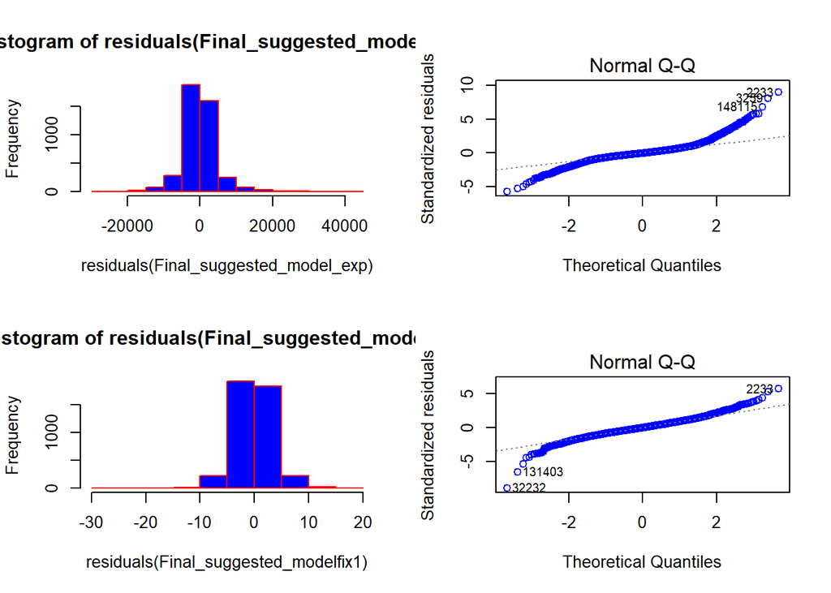

```r
par(mfrow=c(2,2))
hist(residuals(Final_suggested_model_exp),col = "Blue", border = "red")
plot(Final_suggested_model_exp,which=2,col = "blue")
hist(residuals(Final_suggested_modelfix1),col = "Blue", border = "red")
plot(Final_suggested_modelfix1,which=2,col = "blue")
```

$$\begin{aligned}
H_0:&\mbox{ the sample residual is normally distributed}\\
H_a~:&\mbox{ the sample residual is non-normally distributed} \\
\end{aligned}$$

```r
#shapiro.test(residuals(Final_suggested_model_exp))
shapiro.test(residuals(Final_suggested_modelfix1))
```

```
##
##  Shapiro-Wilk normality test
##
## data:  residuals(Final_suggested_modelfix1)
## W = 0.97972, p-value < 2.2e-16
```

Further more, we need to confirm the errors between observed and predicted values are normally distributed. From the histogram, we could see that the normality assumption improved. Then we further checked the normality by Shapiro-Wilk normality test. However, we got P value less then 0.05, indicating that the normality assumption does not pass the Shapiro-Wilk normality test, but at least the distribution become better after the transformation.

#### 2.2.3.4 4. Outlier - The effect on Individual Cases

```r
le <- hatvalues(Final_suggested_modelfix1)
p <- length(coef(Final_suggested_modelfix1))
n <- nrow(samplecardata)
outlier2p = le[le>(2*p/n)]
outlier3p = le[le>(3*p/n)]
```

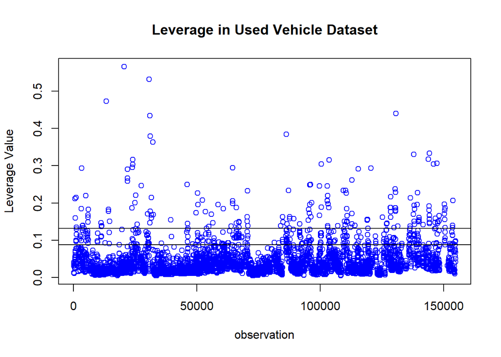

```
            [Verifying if influential observation exist after box-cox transformation]
```

```r
plot(rownames(samplecardata),le, main = "Leverage in Used Vehicle Dataset", xlab="observation",
ylab = "Leverage Value",col = "blue")
abline(h = 2 *p/n, lty = 1)
abline(h = 3 *p/n, lty = 1)
```

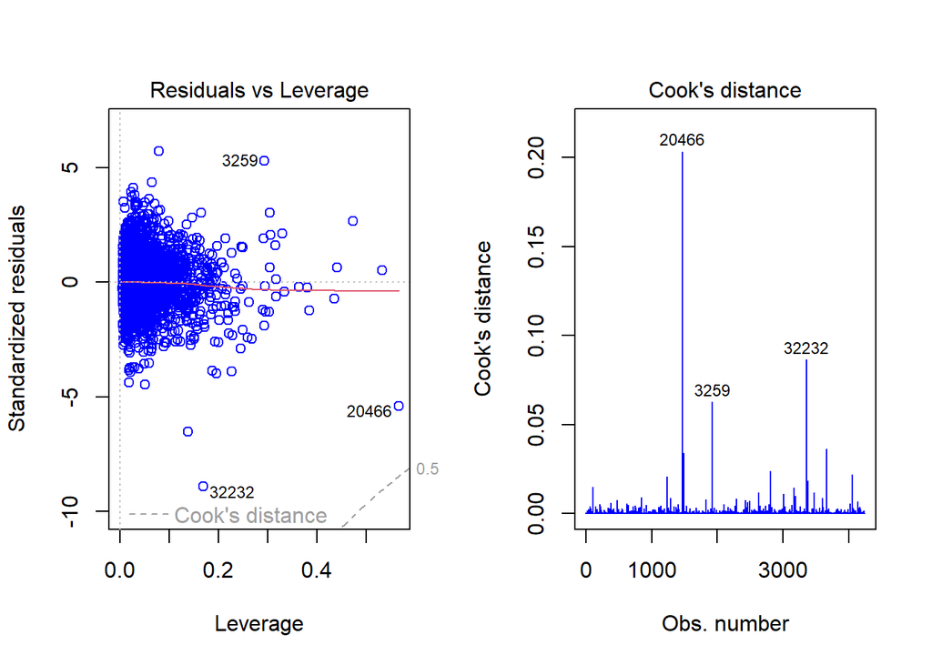

```
            [Verifying if influential outlier exist after box-cox transformation]
```

```r
par(mfrow=c(1,2))
plot(Final_suggested_modelfix1,col = "Blue",which = 5)
plot(Final_suggested_modelfix1,pch = 18, col = "Blue",which = 4)
```

```r
samplecardata[cooks.distance(Final_suggested_modelfix1)>0.5,]
```

| vin | price | miles | make | body_type | vehicle_type | drivetrain | transmission | engine_size | age | make_model | make_body_type | make_model_body_type | RowNum | age_exp | miles_exp |
| --- | --- | --- | --- | --- | --- | --- | --- | --- | --- | --- | --- | --- | --- | --- | --- |

After the transformation we have verified if their are any influence outliers. As we can see from the graphs above. No influential outliers are detected.

## 2.3 Model Evaluation

```r
estimatedvalues_eva1 <- Final_suggested_modelfix1$fitted.values
residualsvalues_eva1 <- Final_suggested_modelfix1$residuals
obsprice1 <- samplecardata$price
df1 = data.frame(cbind(obsprice1,estimatedvalues_eva1,residualsvalues_eva1))
df2=df1 %>% mutate(obsprice_trans1 = ((obsprice1)^boxtransf-1)/boxtransf)
```

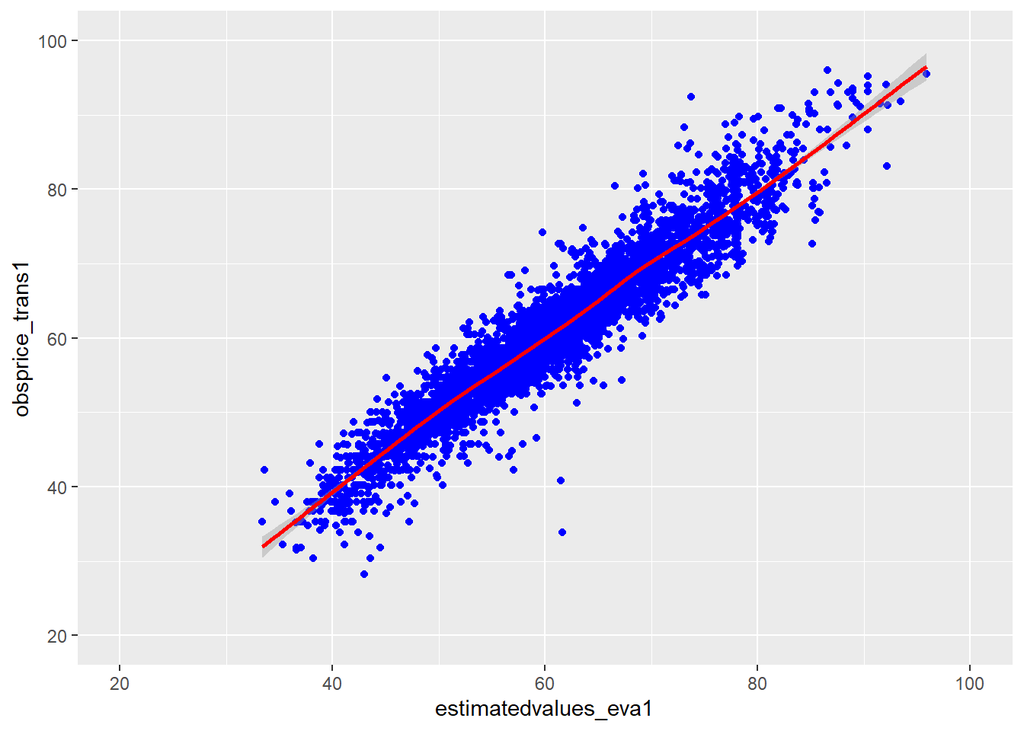

```r
ggplot(df2,aes(x = estimatedvalues_eva1,y=obsprice_trans1))+geom_point(col= "blue")+geom_smooth(col = "red")+ xlim(20, 100)+ylim(20, 100)
```

```r
estimatedvalues_eva <- Final_suggested_modelfix1$fitted.values
estimatedvalues_eva <- cbind(estimatedvalues_eva, "Predicted Price")
obsprice <- samplecardata$price
obsprice_trans <- (((obsprice)^boxtransf-1)/boxtransf)
obsprice_trans <- cbind(obsprice_trans, "Observed Price")

df1 = data.frame(rbind(obsprice_trans,estimatedvalues_eva))
colnames(df1) = c("Price","Class")
df1$Price <- as.numeric(as.character(df1$Price))
```

```r
samplemean = ddply(df1, "Class", summarise, grp.mean = mean(Price),grp.sd = sd(Price),grp.var = var(Price))
samplemean
```

| Class | grp.mean | grp.sd | grp.var |
| --- | --- | --- | --- |
| Observed Price | 60.48349 | 10.69409 | 114.3636 |
| Predicted Price | 60.48349 | 10.16095 | 103.2450 |

[Above Table indicates the difference between observed and predicted price sample mean, standard deviation and variance]

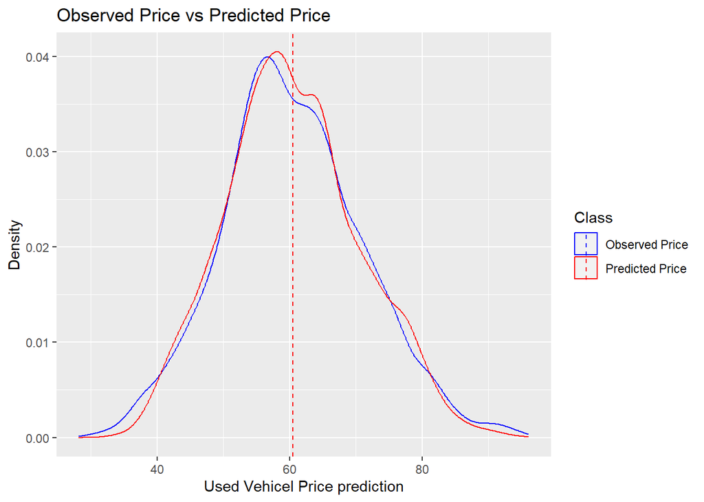

[figure not shown]

Comparing the observed and predicted price

```r
set = ggplot(df1, aes(x = Price, col = Class)) + geom_density(na.rm=TRUE) + xlab("Used Vehicel Price prediction") +ylab("Density")+ ggtitle("Observed Price vs Predicted Price")+geom_vline(data=samplemean, aes(xintercept=grp.mean, color=Class), linetype="dashed")
set+scale_color_manual(values=c( "blue","red"))
```

After the box-cox transformation, we evaluated the model by comparing the predicted price with the observed price, which is the real value of the price. The ideal situation is the predicted price is the same observed price.

In the density plotting, most areas of the observed price are overlapped with the predicted price, indicating the high accuracy of the prediction model.

# 3 Conclusion

Finally, we make a model with 90% accuracy, meaning 90% of the variance could be explained by our final model.

# 4 Discussion

At the end of the project, we believe future improvement could be applied to this project from the below aspects:

- Our model involves variable like make “Year” of the car, but the “Price” was collected over 8 years of the time, so the model we built could violate the “Independence Assumption” because the price could have affected by inflation rate. We could send an email to the original data collector “Market Check”, and see if they could provide the data collection date for each of the data points so we could apply inflation rate to adjust the “Price”. Or at least bring this “data collection” date feature to the data collector so they can add this feature to the data set for future data collection.
- Some special features or upgrades package of the vehicle could also affect the price but we do not have those feature in the data set. For example, whether a vehicle has a remote engine starter feature, backup camera, or sensors etc.

We could try add the above data features into the data set and re-build the model with the new variables and see if we could improve our model accuracy.

# 5 Reference

[1] Government of Canada, Statistics Canada. COVID-19 in Canada: A Six-Month Update on Social and Economic Impacts. 20 Oct. 2020, [link](https://www150.statcan.gc.ca/n1/pub/11-631-x/11-631-x2020003-eng.htm.)

[2] Measuring Price Change for Used Vehicles in the Canadian Consumer Price Index. 18 May 2022, [link](https://www150.statcan.gc.ca/n1/pub/62f0014m/62f0014m2022008-eng.htm).

[3] Used Cars Listings for US & Canada. [link](https://www.kaggle.com/datasets/3ea0a6a45dbd4713a8759988845f1a58038036d84515ded58f65a2ff2bd32e00). Accessed 16 Nov. 2022.